# Home Credit Default Risk (HCDR)

The course project is based on the [Home Credit Default Risk (HCDR) Kaggle Competition](https://www.kaggle.com/c/home-credit-default-risk/). The goal of this project is to predict whether or not a client will repay a loan. In order to make sure that people who struggle to get loans due to insufficient or non-existent credit histories have a positive loan experience, Home Credit makes use of a variety of alternative data--including telco and transactional information--to predict their clients' repayment abilities.

## Some of the challenges

1. Dataset size
   - (688 meg uncompressed) with millions of rows of data
   - 2.71 Gig of data uncompressed
- Dealing with missing data
- Imbalanced datasets
- Summarizing transaction data

# Kaggle API setup

Kaggle is a Data Science Competition Platform which shares a lot of datasets. In the past, it was troublesome to submit your result as your have to go through the console in your browser and drag your files there. Now you can interact with Kaggle via the command line. E.g.,

```
! kaggle competitions files home-credit-default-risk
```

It is quite easy to setup, it takes me less than 15 minutes to finish a submission.

1. Install library
- Create a API Token (edit your profile on [Kaggle.com](https://www.kaggle.com/)); this produces `kaggle.json` file
- Put your JSON `kaggle.json` in the right place
- Access competition files; make submissions via the command (see examples below)
- Submit result

For more detailed information on setting the Kaggle API see [here](https://medium.com/@nokkk/make-your-kaggle-submissions-with-kaggle-official-api-f49093c04f8a) and [here](https://github.com/Kaggle/kaggle-api).

```python
!pip install kaggle
```

```python
!pwd
```

```
/content
```

```python
# !mkdir ~/.kaggle
# !cp /root/shared/Downloads/kaggle.json ~/.kaggle
# !chmod 600 ~/.kaggle/kaggle.json
```

[output not shown]

```python
! kaggle competitions files home-credit-default-risk
```

```
name                                 size  creationDate
----------------------------------  -----  -------------------
installments_payments.csv           690MB  2019-12-11 02:55:35
POS_CASH_balance.csv                375MB  2019-12-11 02:55:35
application_train.csv               158MB  2019-12-11 02:55:35
previous_application.csv            386MB  2019-12-11 02:55:35
credit_card_balance.csv             405MB  2019-12-11 02:55:35
bureau.csv                          162MB  2019-12-11 02:55:35
sample_submission.csv               524KB  2019-12-11 02:55:35
application_test.csv                 25MB  2019-12-11 02:55:35
bureau_balance.csv                  358MB  2019-12-11 02:55:35
HomeCredit_columns_description.csv   37KB  2019-12-11 02:55:35
```

# Dataset and how to download

## Back ground Home Credit Group

Many people struggle to get loans due to insufficient or non-existent credit histories. And, unfortunately, this population is often taken advantage of by untrustworthy lenders.

### Home Credit Group

Home Credit strives to broaden financial inclusion for the unbanked population by providing a positive and safe borrowing experience. In order to make sure this underserved population has a positive loan experience, Home Credit makes use of a variety of alternative data--including telco and transactional information--to predict their clients' repayment abilities.

While Home Credit is currently using various statistical and machine learning methods to make these predictions, they're challenging Kagglers to help them unlock the full potential of their data. Doing so will ensure that clients capable of repayment are not rejected and that loans are given with a principal, maturity, and repayment calendar that will empower their clients to be successful.

## Background on the dataset

Home Credit is a non-banking financial institution, founded in 1997 in the Czech Republic.

The company operates in 14 countries (including United States, Russia, Kazahstan, Belarus, China, India) and focuses on lending primarily to people with little or no credit history which will either not obtain loans or became victims of untrustworthly lenders.

Home Credit group has over 29 million customers, total assests of 21 billions Euro, over 160 millions loans, with the majority in Asia and and almost half of them in China (as of 19-05-2018).

While Home Credit is currently using various statistical and machine learning methods to make these predictions, they're challenging Kagglers to help them unlock the full potential of their data. Doing so will ensure that clients capable of repayment are not rejected and that loans are given with a principal, maturity, and repayment calendar that will empower their clients to be successful.

## Data files overview

There are 7 different sources of data:

- **application_train/application_test:** the main training and testing data with information about each loan application at Home Credit. Every loan has its own row and is identified by the feature SK_ID_CURR. The training application data comes with the TARGET indicating **0: the loan was repaid** or **1: the loan was not repaid**. The target variable defines if the client had payment difficulties meaning he/she had late payment more than X days on at least one of the first Y installments of the loan. Such case is marked as 1 while other all other cases as 0.
- **bureau:** data concerning client's previous credits from other financial institutions. Each previous credit has its own row in bureau, but one loan in the application data can have multiple previous credits.
- **bureau_balance:** monthly data about the previous credits in bureau. Each row is one month of a previous credit, and a single previous credit can have multiple rows, one for each month of the credit length.
- **previous_application:** previous applications for loans at Home Credit of clients who have loans in the application data. Each current loan in the application data can have multiple previous loans. Each previous application has one row and is identified by the feature SK_ID_PREV.
- **POS_CASH_BALANCE:** monthly data about previous point of sale or cash loans clients have had with Home Credit. Each row is one month of a previous point of sale or cash loan, and a single previous loan can have many rows.
- credit_card_balance: monthly data about previous credit cards clients have had with Home Credit. Each row is one month of a credit card balance, and a single credit card can have many rows.
- **installments_payment:** payment history for previous loans at Home Credit. There is one row for every made payment and one row for every missed payment.

```python
# ![alt](home_credit.png "Home credit")
```

```python
from google.colab import drive
drive.mount('/content/gdrive')
```

```python
!mkdir /content/gdrive/MyDrive/.kaggle
!cp /content/gdrive/MyDrive/kaggle.json ~/.kaggle
!chmod 600 ~/.kaggle/kaggle.json
```

```
mkdir: cannot create directory ‘/content/gdrive/MyDrive/.kaggle’: File exists
```

```python
!ls /
```

```
bin	 datalab  home	 lib64	opt	    root  srv		     tmp    var
boot	 dev	  lib	 media	proc	    run   sys		     tools
content  etc	  lib32  mnt	python-apt  sbin  tensorflow-1.15.2  usr
```

## Downloading the files via Kaggle API

Create a base directory:

```
DATA_DIR = "../../../Data/home-credit-default-risk"   #same level as course repo in the data directory
```

Please download the project data files and data dictionary and unzip them using either of the following approaches:

1. Click on the `Download` button on the following [Data Webpage](https://www.kaggle.com/c/home-credit-default-risk/data) and unzip the zip file to the `BASE_DIR`
2. If you plan to use the Kaggle API, please use the following steps.

```python
# DATA_DIR = "Data/home-credit-default-risk"   #same level as course repo in the data directory
DATA_DIR = "/content/gdrive/MyDrive/Colab_Notebooks/Data/home-credit-default-risk"
# DATA_DIR = "/content/gdrive/MyDrive/Data/home-credit-default-risk"
# !mkdir $DATA_DIR
```

```python
!ls -l $DATA_DIR
```

```
total 2621352
-rw------- 1 root root  26567651 Nov  8 21:36 application_test.csv
-rw------- 1 root root 166133370 Nov  8 21:36 application_train.csv
-rw------- 1 root root 375592889 Nov  8 21:36 bureau_balance.csv
-rw------- 1 root root 170016717 Nov  8 21:36 bureau.csv
-rw------- 1 root root 424582605 Nov  8 21:36 credit_card_balance.csv
-rw------- 1 root root     37383 Nov  8 21:36 HomeCredit_columns_description.csv
-rw------- 1 root root 723118349 Nov  8 21:37 installments_payments.csv
-rw------- 1 root root 392703158 Nov  8 21:36 POS_CASH_balance.csv
-rw------- 1 root root 404973293 Nov  8 21:37 previous_application.csv
-rw------- 1 root root    536202 Nov  8 21:37 sample_submission.csv
```

```python
# ! kaggle competitions download home-credit-default-risk -p $DATA_DIR
```

### Imports

```python
import numpy as np
import pandas as pd
from sklearn.preprocessing import LabelEncoder
import os
import zipfile
from sklearn.base import BaseEstimator, TransformerMixin
import matplotlib.pyplot as plt
import seaborn as sns
from sklearn.linear_model import LogisticRegression
from sklearn.model_selection import train_test_split
from sklearn.model_selection import KFold
from sklearn.model_selection import cross_val_score
from sklearn.model_selection import GridSearchCV
from sklearn.impute import SimpleImputer
from sklearn.preprocessing import MinMaxScaler
from sklearn.pipeline import Pipeline, FeatureUnion
from pandas.plotting import scatter_matrix
from sklearn.preprocessing import StandardScaler
from sklearn.preprocessing import OneHotEncoder
import warnings
warnings.filterwarnings('ignore')
```

## Data files overview

### Data Dictionary

As part of the data download comes a Data Dictionary. It named `HomeCredit_columns_description.csv`

### Application train

```python
import numpy as np
import pandas as pd
from sklearn.preprocessing import LabelEncoder
import os
import zipfile
from sklearn.base import BaseEstimator, TransformerMixin
import matplotlib.pyplot as plt
import seaborn as sns
%matplotlib inline
from sklearn.linear_model import LogisticRegression
from sklearn.model_selection import train_test_split
from sklearn.model_selection import KFold
from sklearn.model_selection import cross_val_score
from sklearn.model_selection import GridSearchCV
from sklearn.impute import SimpleImputer
from sklearn.preprocessing import MinMaxScaler
from sklearn.pipeline import Pipeline, FeatureUnion
from pandas.plotting import scatter_matrix
from sklearn.preprocessing import StandardScaler
from sklearn.preprocessing import OneHotEncoder
import warnings
warnings.filterwarnings('ignore')

def load_data(in_path, name):
    df = pd.read_csv(in_path)
    print(f"{name}: shape is {df.shape}")
    print(df.info())
    display(df.head(5))
    return df

datasets={}  # lets store the datasets in a dictionary so we can keep track of them easily
ds_name = 'application_train'
datasets[ds_name] = load_data(DATA_DIR + '/' + ds_name + '.csv', ds_name)

datasets['application_train'].shape
```

```
application_train: shape is (307511, 122)
<class 'pandas.core.frame.DataFrame'>
RangeIndex: 307511 entries, 0 to 307510
Columns: 122 entries, SK_ID_CURR to AMT_REQ_CREDIT_BUREAU_YEAR
dtypes: float64(65), int64(41), object(16)
memory usage: 286.2+ MB
None
```

|  | SK_ID_CURR | TARGET | NAME_CONTRACT_TYPE | CODE_GENDER | FLAG_OWN_CAR | FLAG_OWN_REALTY | CNT_CHILDREN | AMT_INCOME_TOTAL | AMT_CREDIT | AMT_ANNUITY | AMT_GOODS_PRICE | NAME_TYPE_SUITE | NAME_INCOME_TYPE | NAME_EDUCATION_TYPE | NAME_FAMILY_STATUS | NAME_HOUSING_TYPE | REGION_POPULATION_RELATIVE | DAYS_BIRTH | DAYS_EMPLOYED | DAYS_REGISTRATION | DAYS_ID_PUBLISH | OWN_CAR_AGE | FLAG_MOBIL | FLAG_EMP_PHONE | FLAG_WORK_PHONE | FLAG_CONT_MOBILE | FLAG_PHONE | FLAG_EMAIL | OCCUPATION_TYPE | … |
| --- | --- | --- | --- | --- | --- | --- | --- | --- | --- | --- | --- | --- | --- | --- | --- | --- | --- | --- | --- | --- | --- | --- | --- | --- | --- | --- | --- | --- | --- | --- |
| 0 | 100002 | 1 | Cash loans | M | N | Y | 0 | 202500.0 | 406597.5 | 24700.5 | 351000.0 | Unaccompanied | Working | Secondary / secondary special | Single / not married | House / apartment | 0.018801 | -9461 | -637 | -3648.0 | -2120 | NaN | 1 | 1 | 0 | 1 | 1 | 0 | Laborers | … |
| 1 | 100003 | 0 | Cash loans | F | N | N | 0 | 270000.0 | 1293502.5 | 35698.5 | 1129500.0 | Family | State servant | Higher education | Married | House / apartment | 0.003541 | -16765 | -1188 | -1186.0 | -291 | NaN | 1 | 1 | 0 | 1 | 1 | 0 | Core staff | … |
| 2 | 100004 | 0 | Revolving loans | M | Y | Y | 0 | 67500.0 | 135000.0 | 6750.0 | 135000.0 | Unaccompanied | Working | Secondary / secondary special | Single / not married | House / apartment | 0.010032 | -19046 | -225 | -4260.0 | -2531 | 26.0 | 1 | 1 | 1 | 1 | 1 | 0 | Laborers | … |
| 3 | 100006 | 0 | Cash loans | F | N | Y | 0 | 135000.0 | 312682.5 | 29686.5 | 297000.0 | Unaccompanied | Working | Secondary / secondary special | Civil marriage | House / apartment | 0.008019 | -19005 | -3039 | -9833.0 | -2437 | NaN | 1 | 1 | 0 | 1 | 0 | 0 | Laborers | … |
| 4 | 100007 | 0 | Cash loans | M | N | Y | 0 | 121500.0 | 513000.0 | 21865.5 | 513000.0 | Unaccompanied | Working | Secondary / secondary special | Single / not married | House / apartment | 0.028663 | -19932 | -3038 | -4311.0 | -3458 | NaN | 1 | 1 | 0 | 1 | 0 | 0 | Core staff | … |

5 rows × 122 columns

```
(307511, 122)
```

### Application test

- **application_train/application_test:** the main training and testing data with information about each loan application at Home Credit. Every loan has its own row and is identified by the feature SK_ID_CURR. The training application data comes with the TARGET indicating **0: the loan was repaid** or **1: the loan was not repaid**. The target variable defines if the client had payment difficulties meaning he/she had late payment more than X days on at least one of the first Y installments of the loan. Such case is marked as 1 while other all other cases as 0.

```python
ds_name = 'application_test'
datasets[ds_name] = load_data(DATA_DIR + '/' + ds_name + '.csv', ds_name)
```

```
application_test: shape is (48744, 121)
<class 'pandas.core.frame.DataFrame'>
RangeIndex: 48744 entries, 0 to 48743
Columns: 121 entries, SK_ID_CURR to AMT_REQ_CREDIT_BUREAU_YEAR
dtypes: float64(65), int64(40), object(16)
memory usage: 45.0+ MB
None
```

|  | SK_ID_CURR | NAME_CONTRACT_TYPE | CODE_GENDER | FLAG_OWN_CAR | FLAG_OWN_REALTY | CNT_CHILDREN | AMT_INCOME_TOTAL | AMT_CREDIT | AMT_ANNUITY | AMT_GOODS_PRICE | NAME_TYPE_SUITE | NAME_INCOME_TYPE | NAME_EDUCATION_TYPE | NAME_FAMILY_STATUS | NAME_HOUSING_TYPE | REGION_POPULATION_RELATIVE | DAYS_BIRTH | DAYS_EMPLOYED | DAYS_REGISTRATION | DAYS_ID_PUBLISH | OWN_CAR_AGE | FLAG_MOBIL | FLAG_EMP_PHONE | FLAG_WORK_PHONE | FLAG_CONT_MOBILE | FLAG_PHONE | FLAG_EMAIL | OCCUPATION_TYPE | CNT_FAM_MEMBERS | … |
| --- | --- | --- | --- | --- | --- | --- | --- | --- | --- | --- | --- | --- | --- | --- | --- | --- | --- | --- | --- | --- | --- | --- | --- | --- | --- | --- | --- | --- | --- | --- |
| 0 | 100001 | Cash loans | F | N | Y | 0 | 135000.0 | 568800.0 | 20560.5 | 450000.0 | Unaccompanied | Working | Higher education | Married | House / apartment | 0.018850 | -19241 | -2329 | -5170.0 | -812 | NaN | 1 | 1 | 0 | 1 | 0 | 1 | NaN | 2.0 | … |
| 1 | 100005 | Cash loans | M | N | Y | 0 | 99000.0 | 222768.0 | 17370.0 | 180000.0 | Unaccompanied | Working | Secondary / secondary special | Married | House / apartment | 0.035792 | -18064 | -4469 | -9118.0 | -1623 | NaN | 1 | 1 | 0 | 1 | 0 | 0 | Low-skill Laborers | 2.0 | … |
| 2 | 100013 | Cash loans | M | Y | Y | 0 | 202500.0 | 663264.0 | 69777.0 | 630000.0 | NaN | Working | Higher education | Married | House / apartment | 0.019101 | -20038 | -4458 | -2175.0 | -3503 | 5.0 | 1 | 1 | 0 | 1 | 0 | 0 | Drivers | 2.0 | … |
| 3 | 100028 | Cash loans | F | N | Y | 2 | 315000.0 | 1575000.0 | 49018.5 | 1575000.0 | Unaccompanied | Working | Secondary / secondary special | Married | House / apartment | 0.026392 | -13976 | -1866 | -2000.0 | -4208 | NaN | 1 | 1 | 0 | 1 | 1 | 0 | Sales staff | 4.0 | … |
| 4 | 100038 | Cash loans | M | Y | N | 1 | 180000.0 | 625500.0 | 32067.0 | 625500.0 | Unaccompanied | Working | Secondary / secondary special | Married | House / apartment | 0.010032 | -13040 | -2191 | -4000.0 | -4262 | 16.0 | 1 | 1 | 1 | 1 | 0 | 0 | NaN | 3.0 | … |

5 rows × 121 columns

The application dataset has the most information about the client: Gender, income, family status, education ...

### The Other datasets

- **bureau:** data concerning client's previous credits from other financial institutions. Each previous credit has its own row in bureau, but one loan in the application data can have multiple previous credits.
- **bureau_balance:** monthly data about the previous credits in bureau. Each row is one month of a previous credit, and a single previous credit can have multiple rows, one for each month of the credit length.
- **previous_application:** previous applications for loans at Home Credit of clients who have loans in the application data. Each current loan in the application data can have multiple previous loans. Each previous application has one row and is identified by the feature SK_ID_PREV.
- **POS_CASH_BALANCE:** monthly data about previous point of sale or cash loans clients have had with Home Credit. Each row is one month of a previous point of sale or cash loan, and a single previous loan can have many rows.
- credit_card_balance: monthly data about previous credit cards clients have had with Home Credit. Each row is one month of a credit card balance, and a single credit card can have many rows.
- **installments_payment:** payment history for previous loans at Home Credit. There is one row for every made payment and one row for every missed payment.

```python
%%time
ds_names = ("application_train", "application_test", "bureau","bureau_balance","credit_card_balance","installments_payments",
            "previous_application","POS_CASH_balance")

for ds_name in ds_names:
    datasets[ds_name] = load_data(DATA_DIR + '/' + ds_name + '.csv', ds_name)
```

```
application_train: shape is (307511, 122)
<class 'pandas.core.frame.DataFrame'>
RangeIndex: 307511 entries, 0 to 307510
Columns: 122 entries, SK_ID_CURR to AMT_REQ_CREDIT_BUREAU_YEAR
dtypes: float64(65), int64(41), object(16)
memory usage: 286.2+ MB
None
```

|  | SK_ID_CURR | TARGET | NAME_CONTRACT_TYPE | CODE_GENDER | FLAG_OWN_CAR | FLAG_OWN_REALTY | CNT_CHILDREN | AMT_INCOME_TOTAL | AMT_CREDIT | AMT_ANNUITY | AMT_GOODS_PRICE | NAME_TYPE_SUITE | NAME_INCOME_TYPE | NAME_EDUCATION_TYPE | NAME_FAMILY_STATUS | NAME_HOUSING_TYPE | REGION_POPULATION_RELATIVE | DAYS_BIRTH | DAYS_EMPLOYED | DAYS_REGISTRATION | DAYS_ID_PUBLISH | OWN_CAR_AGE | FLAG_MOBIL | FLAG_EMP_PHONE | FLAG_WORK_PHONE | FLAG_CONT_MOBILE | FLAG_PHONE | FLAG_EMAIL | OCCUPATION_TYPE | … |
| --- | --- | --- | --- | --- | --- | --- | --- | --- | --- | --- | --- | --- | --- | --- | --- | --- | --- | --- | --- | --- | --- | --- | --- | --- | --- | --- | --- | --- | --- | --- |
| 0 | 100002 | 1 | Cash loans | M | N | Y | 0 | 202500.0 | 406597.5 | 24700.5 | 351000.0 | Unaccompanied | Working | Secondary / secondary special | Single / not married | House / apartment | 0.018801 | -9461 | -637 | -3648.0 | -2120 | NaN | 1 | 1 | 0 | 1 | 1 | 0 | Laborers | … |
| 1 | 100003 | 0 | Cash loans | F | N | N | 0 | 270000.0 | 1293502.5 | 35698.5 | 1129500.0 | Family | State servant | Higher education | Married | House / apartment | 0.003541 | -16765 | -1188 | -1186.0 | -291 | NaN | 1 | 1 | 0 | 1 | 1 | 0 | Core staff | … |
| 2 | 100004 | 0 | Revolving loans | M | Y | Y | 0 | 67500.0 | 135000.0 | 6750.0 | 135000.0 | Unaccompanied | Working | Secondary / secondary special | Single / not married | House / apartment | 0.010032 | -19046 | -225 | -4260.0 | -2531 | 26.0 | 1 | 1 | 1 | 1 | 1 | 0 | Laborers | … |
| 3 | 100006 | 0 | Cash loans | F | N | Y | 0 | 135000.0 | 312682.5 | 29686.5 | 297000.0 | Unaccompanied | Working | Secondary / secondary special | Civil marriage | House / apartment | 0.008019 | -19005 | -3039 | -9833.0 | -2437 | NaN | 1 | 1 | 0 | 1 | 0 | 0 | Laborers | … |
| 4 | 100007 | 0 | Cash loans | M | N | Y | 0 | 121500.0 | 513000.0 | 21865.5 | 513000.0 | Unaccompanied | Working | Secondary / secondary special | Single / not married | House / apartment | 0.028663 | -19932 | -3038 | -4311.0 | -3458 | NaN | 1 | 1 | 0 | 1 | 0 | 0 | Core staff | … |

5 rows × 122 columns

```
application_test: shape is (48744, 121)
<class 'pandas.core.frame.DataFrame'>
RangeIndex: 48744 entries, 0 to 48743
Columns: 121 entries, SK_ID_CURR to AMT_REQ_CREDIT_BUREAU_YEAR
dtypes: float64(65), int64(40), object(16)
memory usage: 45.0+ MB
None
```

|  | SK_ID_CURR | NAME_CONTRACT_TYPE | CODE_GENDER | FLAG_OWN_CAR | FLAG_OWN_REALTY | CNT_CHILDREN | AMT_INCOME_TOTAL | AMT_CREDIT | AMT_ANNUITY | AMT_GOODS_PRICE | NAME_TYPE_SUITE | NAME_INCOME_TYPE | NAME_EDUCATION_TYPE | NAME_FAMILY_STATUS | NAME_HOUSING_TYPE | REGION_POPULATION_RELATIVE | DAYS_BIRTH | DAYS_EMPLOYED | DAYS_REGISTRATION | DAYS_ID_PUBLISH | OWN_CAR_AGE | FLAG_MOBIL | FLAG_EMP_PHONE | FLAG_WORK_PHONE | FLAG_CONT_MOBILE | FLAG_PHONE | FLAG_EMAIL | OCCUPATION_TYPE | CNT_FAM_MEMBERS | … |
| --- | --- | --- | --- | --- | --- | --- | --- | --- | --- | --- | --- | --- | --- | --- | --- | --- | --- | --- | --- | --- | --- | --- | --- | --- | --- | --- | --- | --- | --- | --- |
| 0 | 100001 | Cash loans | F | N | Y | 0 | 135000.0 | 568800.0 | 20560.5 | 450000.0 | Unaccompanied | Working | Higher education | Married | House / apartment | 0.018850 | -19241 | -2329 | -5170.0 | -812 | NaN | 1 | 1 | 0 | 1 | 0 | 1 | NaN | 2.0 | … |
| 1 | 100005 | Cash loans | M | N | Y | 0 | 99000.0 | 222768.0 | 17370.0 | 180000.0 | Unaccompanied | Working | Secondary / secondary special | Married | House / apartment | 0.035792 | -18064 | -4469 | -9118.0 | -1623 | NaN | 1 | 1 | 0 | 1 | 0 | 0 | Low-skill Laborers | 2.0 | … |
| 2 | 100013 | Cash loans | M | Y | Y | 0 | 202500.0 | 663264.0 | 69777.0 | 630000.0 | NaN | Working | Higher education | Married | House / apartment | 0.019101 | -20038 | -4458 | -2175.0 | -3503 | 5.0 | 1 | 1 | 0 | 1 | 0 | 0 | Drivers | 2.0 | … |
| 3 | 100028 | Cash loans | F | N | Y | 2 | 315000.0 | 1575000.0 | 49018.5 | 1575000.0 | Unaccompanied | Working | Secondary / secondary special | Married | House / apartment | 0.026392 | -13976 | -1866 | -2000.0 | -4208 | NaN | 1 | 1 | 0 | 1 | 1 | 0 | Sales staff | 4.0 | … |
| 4 | 100038 | Cash loans | M | Y | N | 1 | 180000.0 | 625500.0 | 32067.0 | 625500.0 | Unaccompanied | Working | Secondary / secondary special | Married | House / apartment | 0.010032 | -13040 | -2191 | -4000.0 | -4262 | 16.0 | 1 | 1 | 1 | 1 | 0 | 0 | NaN | 3.0 | … |

5 rows × 121 columns

```
bureau: shape is (1716428, 17)
<class 'pandas.core.frame.DataFrame'>
RangeIndex: 1716428 entries, 0 to 1716427
Data columns (total 17 columns):
 #   Column                  Dtype
---  ------                  -----
 0   SK_ID_CURR              int64
 1   SK_ID_BUREAU            int64
 2   CREDIT_ACTIVE           object
 3   CREDIT_CURRENCY         object
 4   DAYS_CREDIT             int64
 5   CREDIT_DAY_OVERDUE      int64
 6   DAYS_CREDIT_ENDDATE     float64
 7   DAYS_ENDDATE_FACT       float64
 8   AMT_CREDIT_MAX_OVERDUE  float64
 9   CNT_CREDIT_PROLONG      int64
 10  AMT_CREDIT_SUM          float64
 11  AMT_CREDIT_SUM_DEBT     float64
 12  AMT_CREDIT_SUM_LIMIT    float64
 13  AMT_CREDIT_SUM_OVERDUE  float64
 14  CREDIT_TYPE             object
 15  DAYS_CREDIT_UPDATE      int64
 16  AMT_ANNUITY             float64
dtypes: float64(8), int64(6), object(3)
memory usage: 222.6+ MB
None
```

|  | SK_ID_CURR | SK_ID_BUREAU | CREDIT_ACTIVE | CREDIT_CURRENCY | DAYS_CREDIT | CREDIT_DAY_OVERDUE | DAYS_CREDIT_ENDDATE | DAYS_ENDDATE_FACT | AMT_CREDIT_MAX_OVERDUE | CNT_CREDIT_PROLONG | AMT_CREDIT_SUM | AMT_CREDIT_SUM_DEBT | AMT_CREDIT_SUM_LIMIT | AMT_CREDIT_SUM_OVERDUE | CREDIT_TYPE | DAYS_CREDIT_UPDATE | AMT_ANNUITY |
| --- | --- | --- | --- | --- | --- | --- | --- | --- | --- | --- | --- | --- | --- | --- | --- | --- | --- |
| 0 | 215354 | 5714462 | Closed | currency 1 | -497 | 0 | -153.0 | -153.0 | NaN | 0 | 91323.0 | 0.0 | NaN | 0.0 | Consumer credit | -131 | NaN |
| 1 | 215354 | 5714463 | Active | currency 1 | -208 | 0 | 1075.0 | NaN | NaN | 0 | 225000.0 | 171342.0 | NaN | 0.0 | Credit card | -20 | NaN |
| 2 | 215354 | 5714464 | Active | currency 1 | -203 | 0 | 528.0 | NaN | NaN | 0 | 464323.5 | NaN | NaN | 0.0 | Consumer credit | -16 | NaN |
| 3 | 215354 | 5714465 | Active | currency 1 | -203 | 0 | NaN | NaN | NaN | 0 | 90000.0 | NaN | NaN | 0.0 | Credit card | -16 | NaN |
| 4 | 215354 | 5714466 | Active | currency 1 | -629 | 0 | 1197.0 | NaN | 77674.5 | 0 | 2700000.0 | NaN | NaN | 0.0 | Consumer credit | -21 | NaN |

```
bureau_balance: shape is (27299925, 3)
<class 'pandas.core.frame.DataFrame'>
RangeIndex: 27299925 entries, 0 to 27299924
Data columns (total 3 columns):
 #   Column          Dtype
---  ------          -----
 0   SK_ID_BUREAU    int64
 1   MONTHS_BALANCE  int64
 2   STATUS          object
dtypes: int64(2), object(1)
memory usage: 624.8+ MB
None
```

|  | SK_ID_BUREAU | MONTHS_BALANCE | STATUS |
| --- | --- | --- | --- |
| 0 | 5715448 | 0 | C |
| 1 | 5715448 | -1 | C |
| 2 | 5715448 | -2 | C |
| 3 | 5715448 | -3 | C |
| 4 | 5715448 | -4 | C |

```
credit_card_balance: shape is (3840312, 23)
<class 'pandas.core.frame.DataFrame'>
RangeIndex: 3840312 entries, 0 to 3840311
Data columns (total 23 columns):
 #   Column                      Dtype
---  ------                      -----
 0   SK_ID_PREV                  int64
 1   SK_ID_CURR                  int64
 2   MONTHS_BALANCE              int64
 3   AMT_BALANCE                 float64
 4   AMT_CREDIT_LIMIT_ACTUAL     int64
 5   AMT_DRAWINGS_ATM_CURRENT    float64
 6   AMT_DRAWINGS_CURRENT        float64
 7   AMT_DRAWINGS_OTHER_CURRENT  float64
 8   AMT_DRAWINGS_POS_CURRENT    float64
```

[output cut: 17 more lines]

|  | SK_ID_PREV | SK_ID_CURR | MONTHS_BALANCE | AMT_BALANCE | AMT_CREDIT_LIMIT_ACTUAL | AMT_DRAWINGS_ATM_CURRENT | AMT_DRAWINGS_CURRENT | AMT_DRAWINGS_OTHER_CURRENT | AMT_DRAWINGS_POS_CURRENT | AMT_INST_MIN_REGULARITY | AMT_PAYMENT_CURRENT | AMT_PAYMENT_TOTAL_CURRENT | AMT_RECEIVABLE_PRINCIPAL | AMT_RECIVABLE | AMT_TOTAL_RECEIVABLE | CNT_DRAWINGS_ATM_CURRENT | CNT_DRAWINGS_CURRENT | CNT_DRAWINGS_OTHER_CURRENT | CNT_DRAWINGS_POS_CURRENT | CNT_INSTALMENT_MATURE_CUM | NAME_CONTRACT_STATUS | SK_DPD | SK_DPD_DEF |
| --- | --- | --- | --- | --- | --- | --- | --- | --- | --- | --- | --- | --- | --- | --- | --- | --- | --- | --- | --- | --- | --- | --- | --- |
| 0 | 2562384 | 378907 | -6 | 56.970 | 135000 | 0.0 | 877.5 | 0.0 | 877.5 | 1700.325 | 1800.0 | 1800.0 | 0.000 | 0.000 | 0.000 | 0.0 | 1 | 0.0 | 1.0 | 35.0 | Active | 0 | 0 |
| 1 | 2582071 | 363914 | -1 | 63975.555 | 45000 | 2250.0 | 2250.0 | 0.0 | 0.0 | 2250.000 | 2250.0 | 2250.0 | 60175.080 | 64875.555 | 64875.555 | 1.0 | 1 | 0.0 | 0.0 | 69.0 | Active | 0 | 0 |
| 2 | 1740877 | 371185 | -7 | 31815.225 | 450000 | 0.0 | 0.0 | 0.0 | 0.0 | 2250.000 | 2250.0 | 2250.0 | 26926.425 | 31460.085 | 31460.085 | 0.0 | 0 | 0.0 | 0.0 | 30.0 | Active | 0 | 0 |
| 3 | 1389973 | 337855 | -4 | 236572.110 | 225000 | 2250.0 | 2250.0 | 0.0 | 0.0 | 11795.760 | 11925.0 | 11925.0 | 224949.285 | 233048.970 | 233048.970 | 1.0 | 1 | 0.0 | 0.0 | 10.0 | Active | 0 | 0 |
| 4 | 1891521 | 126868 | -1 | 453919.455 | 450000 | 0.0 | 11547.0 | 0.0 | 11547.0 | 22924.890 | 27000.0 | 27000.0 | 443044.395 | 453919.455 | 453919.455 | 0.0 | 1 | 0.0 | 1.0 | 101.0 | Active | 0 | 0 |

```
installments_payments: shape is (13605401, 8)
<class 'pandas.core.frame.DataFrame'>
RangeIndex: 13605401 entries, 0 to 13605400
Data columns (total 8 columns):
 #   Column                  Dtype
---  ------                  -----
 0   SK_ID_PREV              int64
 1   SK_ID_CURR              int64
 2   NUM_INSTALMENT_VERSION  float64
 3   NUM_INSTALMENT_NUMBER   int64
 4   DAYS_INSTALMENT         float64
 5   DAYS_ENTRY_PAYMENT      float64
 6   AMT_INSTALMENT          float64
 7   AMT_PAYMENT             float64
dtypes: float64(5), int64(3)
memory usage: 830.4 MB
None
```

|  | SK_ID_PREV | SK_ID_CURR | NUM_INSTALMENT_VERSION | NUM_INSTALMENT_NUMBER | DAYS_INSTALMENT | DAYS_ENTRY_PAYMENT | AMT_INSTALMENT | AMT_PAYMENT |
| --- | --- | --- | --- | --- | --- | --- | --- | --- |
| 0 | 1054186 | 161674 | 1.0 | 6 | -1180.0 | -1187.0 | 6948.360 | 6948.360 |
| 1 | 1330831 | 151639 | 0.0 | 34 | -2156.0 | -2156.0 | 1716.525 | 1716.525 |
| 2 | 2085231 | 193053 | 2.0 | 1 | -63.0 | -63.0 | 25425.000 | 25425.000 |
| 3 | 2452527 | 199697 | 1.0 | 3 | -2418.0 | -2426.0 | 24350.130 | 24350.130 |
| 4 | 2714724 | 167756 | 1.0 | 2 | -1383.0 | -1366.0 | 2165.040 | 2160.585 |

```
previous_application: shape is (1670214, 37)
<class 'pandas.core.frame.DataFrame'>
RangeIndex: 1670214 entries, 0 to 1670213
Data columns (total 37 columns):
 #   Column                       Non-Null Count    Dtype
---  ------                       --------------    -----
 0   SK_ID_PREV                   1670214 non-null  int64
 1   SK_ID_CURR                   1670214 non-null  int64
 2   NAME_CONTRACT_TYPE           1670214 non-null  object
 3   AMT_ANNUITY                  1297979 non-null  float64
 4   AMT_APPLICATION              1670214 non-null  float64
 5   AMT_CREDIT                   1670213 non-null  float64
 6   AMT_DOWN_PAYMENT             774370 non-null   float64
 7   AMT_GOODS_PRICE              1284699 non-null  float64
 8   WEEKDAY_APPR_PROCESS_START   1670214 non-null  object
```

[output cut: 31 more lines]

|  | SK_ID_PREV | SK_ID_CURR | NAME_CONTRACT_TYPE | AMT_ANNUITY | AMT_APPLICATION | AMT_CREDIT | AMT_DOWN_PAYMENT | AMT_GOODS_PRICE | WEEKDAY_APPR_PROCESS_START | HOUR_APPR_PROCESS_START | FLAG_LAST_APPL_PER_CONTRACT | NFLAG_LAST_APPL_IN_DAY | RATE_DOWN_PAYMENT | RATE_INTEREST_PRIMARY | RATE_INTEREST_PRIVILEGED | NAME_CASH_LOAN_PURPOSE | NAME_CONTRACT_STATUS | DAYS_DECISION | NAME_PAYMENT_TYPE | CODE_REJECT_REASON | NAME_TYPE_SUITE | NAME_CLIENT_TYPE | NAME_GOODS_CATEGORY | NAME_PORTFOLIO | NAME_PRODUCT_TYPE | CHANNEL_TYPE | SELLERPLACE_AREA | NAME_SELLER_INDUSTRY | CNT_PAYMENT | … |
| --- | --- | --- | --- | --- | --- | --- | --- | --- | --- | --- | --- | --- | --- | --- | --- | --- | --- | --- | --- | --- | --- | --- | --- | --- | --- | --- | --- | --- | --- | --- |
| 0 | 2030495 | 271877 | Consumer loans | 1730.430 | 17145.0 | 17145.0 | 0.0 | 17145.0 | SATURDAY | 15 | Y | 1 | 0.0 | 0.182832 | 0.867336 | XAP | Approved | -73 | Cash through the bank | XAP | NaN | Repeater | Mobile | POS | XNA | Country-wide | 35 | Connectivity | 12.0 | … |
| 1 | 2802425 | 108129 | Cash loans | 25188.615 | 607500.0 | 679671.0 | NaN | 607500.0 | THURSDAY | 11 | Y | 1 | NaN | NaN | NaN | XNA | Approved | -164 | XNA | XAP | Unaccompanied | Repeater | XNA | Cash | x-sell | Contact center | -1 | XNA | 36.0 | … |
| 2 | 2523466 | 122040 | Cash loans | 15060.735 | 112500.0 | 136444.5 | NaN | 112500.0 | TUESDAY | 11 | Y | 1 | NaN | NaN | NaN | XNA | Approved | -301 | Cash through the bank | XAP | Spouse, partner | Repeater | XNA | Cash | x-sell | Credit and cash offices | -1 | XNA | 12.0 | … |
| 3 | 2819243 | 176158 | Cash loans | 47041.335 | 450000.0 | 470790.0 | NaN | 450000.0 | MONDAY | 7 | Y | 1 | NaN | NaN | NaN | XNA | Approved | -512 | Cash through the bank | XAP | NaN | Repeater | XNA | Cash | x-sell | Credit and cash offices | -1 | XNA | 12.0 | … |
| 4 | 1784265 | 202054 | Cash loans | 31924.395 | 337500.0 | 404055.0 | NaN | 337500.0 | THURSDAY | 9 | Y | 1 | NaN | NaN | NaN | Repairs | Refused | -781 | Cash through the bank | HC | NaN | Repeater | XNA | Cash | walk-in | Credit and cash offices | -1 | XNA | 24.0 | … |

```
POS_CASH_balance: shape is (10001358, 8)
<class 'pandas.core.frame.DataFrame'>
RangeIndex: 10001358 entries, 0 to 10001357
Data columns (total 8 columns):
 #   Column                 Dtype
---  ------                 -----
 0   SK_ID_PREV             int64
 1   SK_ID_CURR             int64
 2   MONTHS_BALANCE         int64
 3   CNT_INSTALMENT         float64
 4   CNT_INSTALMENT_FUTURE  float64
 5   NAME_CONTRACT_STATUS   object
 6   SK_DPD                 int64
 7   SK_DPD_DEF             int64
dtypes: float64(2), int64(5), object(1)
memory usage: 610.4+ MB
None
```

|  | SK_ID_PREV | SK_ID_CURR | MONTHS_BALANCE | CNT_INSTALMENT | CNT_INSTALMENT_FUTURE | NAME_CONTRACT_STATUS | SK_DPD | SK_DPD_DEF |
| --- | --- | --- | --- | --- | --- | --- | --- | --- |
| 0 | 1803195 | 182943 | -31 | 48.0 | 45.0 | Active | 0 | 0 |
| 1 | 1715348 | 367990 | -33 | 36.0 | 35.0 | Active | 0 | 0 |
| 2 | 1784872 | 397406 | -32 | 12.0 | 9.0 | Active | 0 | 0 |
| 3 | 1903291 | 269225 | -35 | 48.0 | 42.0 | Active | 0 | 0 |
| 4 | 2341044 | 334279 | -35 | 36.0 | 35.0 | Active | 0 | 0 |

```
CPU times: user 38.1 s, sys: 4.17 s, total: 42.3 s
Wall time: 57.8 s
```

# Exploratory Data Analysis

## Summary of Entire dataset

```python
print('\033[1m' + "Size of each dataset : " + '\033[0m' , end = '\n' * 1)
for ds_name in datasets.keys():
    print(f'dataset {ds_name:25}: [ {datasets[ds_name].shape[0],}, {datasets[ds_name].shape[1]}]')
```

```
Size of each dataset :
dataset application_train        : [ (307511,), 122]
dataset application_test         : [ (48744,), 121]
dataset bureau                   : [ (1716428,), 17]
dataset bureau_balance           : [ (27299925,), 3]
dataset credit_card_balance      : [ (3840312,), 23]
dataset installments_payments    : [ (13605401,), 8]
dataset previous_application     : [ (1670214,), 37]
dataset POS_CASH_balance         : [ (10001358,), 8]
```

## Summary of Application train

```python
datasets["application_train"].info()
```

```
<class 'pandas.core.frame.DataFrame'>
RangeIndex: 307511 entries, 0 to 307510
Columns: 122 entries, SK_ID_CURR to AMT_REQ_CREDIT_BUREAU_YEAR
dtypes: float64(65), int64(41), object(16)
memory usage: 286.2+ MB
```

```python
datasets["application_train"].describe() #numerical only features
```

|  | SK_ID_CURR | TARGET | CNT_CHILDREN | AMT_INCOME_TOTAL | AMT_CREDIT | AMT_ANNUITY | AMT_GOODS_PRICE | REGION_POPULATION_RELATIVE | DAYS_BIRTH | DAYS_EMPLOYED | DAYS_REGISTRATION | DAYS_ID_PUBLISH | OWN_CAR_AGE | FLAG_MOBIL | FLAG_EMP_PHONE | FLAG_WORK_PHONE | FLAG_CONT_MOBILE | FLAG_PHONE | FLAG_EMAIL | CNT_FAM_MEMBERS | REGION_RATING_CLIENT | REGION_RATING_CLIENT_W_CITY | HOUR_APPR_PROCESS_START | REG_REGION_NOT_LIVE_REGION | REG_REGION_NOT_WORK_REGION | LIVE_REGION_NOT_WORK_REGION | REG_CITY_NOT_LIVE_CITY | REG_CITY_NOT_WORK_CITY | LIVE_CITY_NOT_WORK_CITY | … |
| --- | --- | --- | --- | --- | --- | --- | --- | --- | --- | --- | --- | --- | --- | --- | --- | --- | --- | --- | --- | --- | --- | --- | --- | --- | --- | --- | --- | --- | --- | --- |
| count | 307511.000000 | 307511.000000 | 307511.000000 | 3.075110e+05 | 3.075110e+05 | 307499.000000 | 3.072330e+05 | 307511.000000 | 307511.000000 | 307511.000000 | 307511.000000 | 307511.000000 | 104582.000000 | 307511.000000 | 307511.000000 | 307511.000000 | 307511.000000 | 307511.000000 | 307511.000000 | 307509.000000 | 307511.000000 | 307511.000000 | 307511.000000 | 307511.000000 | 307511.000000 | 307511.000000 | 307511.000000 | 307511.000000 | 307511.000000 | … |
| mean | 278180.518577 | 0.080729 | 0.417052 | 1.687979e+05 | 5.990260e+05 | 27108.573909 | 5.383962e+05 | 0.020868 | -16036.995067 | 63815.045904 | -4986.120328 | -2994.202373 | 12.061091 | 0.999997 | 0.819889 | 0.199368 | 0.998133 | 0.281066 | 0.056720 | 2.152665 | 2.052463 | 2.031521 | 12.063419 | 0.015144 | 0.050769 | 0.040659 | 0.078173 | 0.230454 | 0.179555 | … |
| std | 102790.175348 | 0.272419 | 0.722121 | 2.371231e+05 | 4.024908e+05 | 14493.737315 | 3.694465e+05 | 0.013831 | 4363.988632 | 141275.766519 | 3522.886321 | 1509.450419 | 11.944812 | 0.001803 | 0.384280 | 0.399526 | 0.043164 | 0.449521 | 0.231307 | 0.910682 | 0.509034 | 0.502737 | 3.265832 | 0.122126 | 0.219526 | 0.197499 | 0.268444 | 0.421124 | 0.383817 | … |
| min | 100002.000000 | 0.000000 | 0.000000 | 2.565000e+04 | 4.500000e+04 | 1615.500000 | 4.050000e+04 | 0.000290 | -25229.000000 | -17912.000000 | -24672.000000 | -7197.000000 | 0.000000 | 0.000000 | 0.000000 | 0.000000 | 0.000000 | 0.000000 | 0.000000 | 1.000000 | 1.000000 | 1.000000 | 0.000000 | 0.000000 | 0.000000 | 0.000000 | 0.000000 | 0.000000 | 0.000000 | … |
| 25% | 189145.500000 | 0.000000 | 0.000000 | 1.125000e+05 | 2.700000e+05 | 16524.000000 | 2.385000e+05 | 0.010006 | -19682.000000 | -2760.000000 | -7479.500000 | -4299.000000 | 5.000000 | 1.000000 | 1.000000 | 0.000000 | 1.000000 | 0.000000 | 0.000000 | 2.000000 | 2.000000 | 2.000000 | 10.000000 | 0.000000 | 0.000000 | 0.000000 | 0.000000 | 0.000000 | 0.000000 | … |
| 50% | 278202.000000 | 0.000000 | 0.000000 | 1.471500e+05 | 5.135310e+05 | 24903.000000 | 4.500000e+05 | 0.018850 | -15750.000000 | -1213.000000 | -4504.000000 | -3254.000000 | 9.000000 | 1.000000 | 1.000000 | 0.000000 | 1.000000 | 0.000000 | 0.000000 | 2.000000 | 2.000000 | 2.000000 | 12.000000 | 0.000000 | 0.000000 | 0.000000 | 0.000000 | 0.000000 | 0.000000 | … |
| 75% | 367142.500000 | 0.000000 | 1.000000 | 2.025000e+05 | 8.086500e+05 | 34596.000000 | 6.795000e+05 | 0.028663 | -12413.000000 | -289.000000 | -2010.000000 | -1720.000000 | 15.000000 | 1.000000 | 1.000000 | 0.000000 | 1.000000 | 1.000000 | 0.000000 | 3.000000 | 2.000000 | 2.000000 | 14.000000 | 0.000000 | 0.000000 | 0.000000 | 0.000000 | 0.000000 | 0.000000 | … |
| max | 456255.000000 | 1.000000 | 19.000000 | 1.170000e+08 | 4.050000e+06 | 258025.500000 | 4.050000e+06 | 0.072508 | -7489.000000 | 365243.000000 | 0.000000 | 0.000000 | 91.000000 | 1.000000 | 1.000000 | 1.000000 | 1.000000 | 1.000000 | 1.000000 | 20.000000 | 3.000000 | 3.000000 | 23.000000 | 1.000000 | 1.000000 | 1.000000 | 1.000000 | 1.000000 | 1.000000 | … |

8 rows × 106 columns

```python
datasets["application_test"].describe() #numerical only features
```

|  | SK_ID_CURR | CNT_CHILDREN | AMT_INCOME_TOTAL | AMT_CREDIT | AMT_ANNUITY | AMT_GOODS_PRICE | REGION_POPULATION_RELATIVE | DAYS_BIRTH | DAYS_EMPLOYED | DAYS_REGISTRATION | DAYS_ID_PUBLISH | OWN_CAR_AGE | FLAG_MOBIL | FLAG_EMP_PHONE | FLAG_WORK_PHONE | FLAG_CONT_MOBILE | FLAG_PHONE | FLAG_EMAIL | CNT_FAM_MEMBERS | REGION_RATING_CLIENT | REGION_RATING_CLIENT_W_CITY | HOUR_APPR_PROCESS_START | REG_REGION_NOT_LIVE_REGION | REG_REGION_NOT_WORK_REGION | LIVE_REGION_NOT_WORK_REGION | REG_CITY_NOT_LIVE_CITY | REG_CITY_NOT_WORK_CITY | LIVE_CITY_NOT_WORK_CITY | EXT_SOURCE_1 | … |
| --- | --- | --- | --- | --- | --- | --- | --- | --- | --- | --- | --- | --- | --- | --- | --- | --- | --- | --- | --- | --- | --- | --- | --- | --- | --- | --- | --- | --- | --- | --- |
| count | 48744.000000 | 48744.000000 | 4.874400e+04 | 4.874400e+04 | 48720.000000 | 4.874400e+04 | 48744.000000 | 48744.000000 | 48744.000000 | 48744.000000 | 48744.000000 | 16432.000000 | 48744.000000 | 48744.000000 | 48744.000000 | 48744.000000 | 48744.000000 | 48744.000000 | 48744.000000 | 48744.000000 | 48744.000000 | 48744.000000 | 48744.000000 | 48744.000000 | 48744.000000 | 48744.000000 | 48744.000000 | 48744.000000 | 28212.000000 | … |
| mean | 277796.676350 | 0.397054 | 1.784318e+05 | 5.167404e+05 | 29426.240209 | 4.626188e+05 | 0.021226 | -16068.084605 | 67485.366322 | -4967.652716 | -3051.712949 | 11.786027 | 0.999979 | 0.809720 | 0.204702 | 0.998400 | 0.263130 | 0.162646 | 2.146767 | 2.038159 | 2.012596 | 12.007365 | 0.018833 | 0.055166 | 0.042036 | 0.077466 | 0.224664 | 0.174216 | 0.501180 | … |
| std | 103169.547296 | 0.709047 | 1.015226e+05 | 3.653970e+05 | 16016.368315 | 3.367102e+05 | 0.014428 | 4325.900393 | 144348.507136 | 3552.612035 | 1569.276709 | 11.462889 | 0.004529 | 0.392526 | 0.403488 | 0.039971 | 0.440337 | 0.369046 | 0.890423 | 0.522694 | 0.515804 | 3.278172 | 0.135937 | 0.228306 | 0.200673 | 0.267332 | 0.417365 | 0.379299 | 0.205142 | … |
| min | 100001.000000 | 0.000000 | 2.694150e+04 | 4.500000e+04 | 2295.000000 | 4.500000e+04 | 0.000253 | -25195.000000 | -17463.000000 | -23722.000000 | -6348.000000 | 0.000000 | 0.000000 | 0.000000 | 0.000000 | 0.000000 | 0.000000 | 0.000000 | 1.000000 | 1.000000 | -1.000000 | 0.000000 | 0.000000 | 0.000000 | 0.000000 | 0.000000 | 0.000000 | 0.000000 | 0.013458 | … |
| 25% | 188557.750000 | 0.000000 | 1.125000e+05 | 2.606400e+05 | 17973.000000 | 2.250000e+05 | 0.010006 | -19637.000000 | -2910.000000 | -7459.250000 | -4448.000000 | 4.000000 | 1.000000 | 1.000000 | 0.000000 | 1.000000 | 0.000000 | 0.000000 | 2.000000 | 2.000000 | 2.000000 | 10.000000 | 0.000000 | 0.000000 | 0.000000 | 0.000000 | 0.000000 | 0.000000 | 0.343695 | … |
| 50% | 277549.000000 | 0.000000 | 1.575000e+05 | 4.500000e+05 | 26199.000000 | 3.960000e+05 | 0.018850 | -15785.000000 | -1293.000000 | -4490.000000 | -3234.000000 | 9.000000 | 1.000000 | 1.000000 | 0.000000 | 1.000000 | 0.000000 | 0.000000 | 2.000000 | 2.000000 | 2.000000 | 12.000000 | 0.000000 | 0.000000 | 0.000000 | 0.000000 | 0.000000 | 0.000000 | 0.506771 | … |
| 75% | 367555.500000 | 1.000000 | 2.250000e+05 | 6.750000e+05 | 37390.500000 | 6.300000e+05 | 0.028663 | -12496.000000 | -296.000000 | -1901.000000 | -1706.000000 | 15.000000 | 1.000000 | 1.000000 | 0.000000 | 1.000000 | 1.000000 | 0.000000 | 3.000000 | 2.000000 | 2.000000 | 14.000000 | 0.000000 | 0.000000 | 0.000000 | 0.000000 | 0.000000 | 0.000000 | 0.665956 | … |
| max | 456250.000000 | 20.000000 | 4.410000e+06 | 2.245500e+06 | 180576.000000 | 2.245500e+06 | 0.072508 | -7338.000000 | 365243.000000 | 0.000000 | 0.000000 | 74.000000 | 1.000000 | 1.000000 | 1.000000 | 1.000000 | 1.000000 | 1.000000 | 21.000000 | 3.000000 | 3.000000 | 23.000000 | 1.000000 | 1.000000 | 1.000000 | 1.000000 | 1.000000 | 1.000000 | 0.939145 | … |

8 rows × 105 columns

```python
datasets["application_train"].describe(include='all') #look at all categorical and numerical
```

|  | SK_ID_CURR | TARGET | NAME_CONTRACT_TYPE | CODE_GENDER | FLAG_OWN_CAR | FLAG_OWN_REALTY | CNT_CHILDREN | AMT_INCOME_TOTAL | AMT_CREDIT | AMT_ANNUITY | AMT_GOODS_PRICE | NAME_TYPE_SUITE | NAME_INCOME_TYPE | NAME_EDUCATION_TYPE | NAME_FAMILY_STATUS | NAME_HOUSING_TYPE | REGION_POPULATION_RELATIVE | DAYS_BIRTH | DAYS_EMPLOYED | DAYS_REGISTRATION | DAYS_ID_PUBLISH | OWN_CAR_AGE | FLAG_MOBIL | FLAG_EMP_PHONE | FLAG_WORK_PHONE | FLAG_CONT_MOBILE | FLAG_PHONE | FLAG_EMAIL | OCCUPATION_TYPE | … |
| --- | --- | --- | --- | --- | --- | --- | --- | --- | --- | --- | --- | --- | --- | --- | --- | --- | --- | --- | --- | --- | --- | --- | --- | --- | --- | --- | --- | --- | --- | --- |
| count | 307511.000000 | 307511.000000 | 307511 | 307511 | 307511 | 307511 | 307511.000000 | 3.075110e+05 | 3.075110e+05 | 307499.000000 | 3.072330e+05 | 306219 | 307511 | 307511 | 307511 | 307511 | 307511.000000 | 307511.000000 | 307511.000000 | 307511.000000 | 307511.000000 | 104582.000000 | 307511.000000 | 307511.000000 | 307511.000000 | 307511.000000 | 307511.000000 | 307511.000000 | 211120 | … |
| unique | NaN | NaN | 2 | 3 | 2 | 2 | NaN | NaN | NaN | NaN | NaN | 7 | 8 | 5 | 6 | 6 | NaN | NaN | NaN | NaN | NaN | NaN | NaN | NaN | NaN | NaN | NaN | NaN | 18 | … |
| top | NaN | NaN | Cash loans | F | N | Y | NaN | NaN | NaN | NaN | NaN | Unaccompanied | Working | Secondary / secondary special | Married | House / apartment | NaN | NaN | NaN | NaN | NaN | NaN | NaN | NaN | NaN | NaN | NaN | NaN | Laborers | … |
| freq | NaN | NaN | 278232 | 202448 | 202924 | 213312 | NaN | NaN | NaN | NaN | NaN | 248526 | 158774 | 218391 | 196432 | 272868 | NaN | NaN | NaN | NaN | NaN | NaN | NaN | NaN | NaN | NaN | NaN | NaN | 55186 | … |
| mean | 278180.518577 | 0.080729 | NaN | NaN | NaN | NaN | 0.417052 | 1.687979e+05 | 5.990260e+05 | 27108.573909 | 5.383962e+05 | NaN | NaN | NaN | NaN | NaN | 0.020868 | -16036.995067 | 63815.045904 | -4986.120328 | -2994.202373 | 12.061091 | 0.999997 | 0.819889 | 0.199368 | 0.998133 | 0.281066 | 0.056720 | NaN | … |
| std | 102790.175348 | 0.272419 | NaN | NaN | NaN | NaN | 0.722121 | 2.371231e+05 | 4.024908e+05 | 14493.737315 | 3.694465e+05 | NaN | NaN | NaN | NaN | NaN | 0.013831 | 4363.988632 | 141275.766519 | 3522.886321 | 1509.450419 | 11.944812 | 0.001803 | 0.384280 | 0.399526 | 0.043164 | 0.449521 | 0.231307 | NaN | … |
| min | 100002.000000 | 0.000000 | NaN | NaN | NaN | NaN | 0.000000 | 2.565000e+04 | 4.500000e+04 | 1615.500000 | 4.050000e+04 | NaN | NaN | NaN | NaN | NaN | 0.000290 | -25229.000000 | -17912.000000 | -24672.000000 | -7197.000000 | 0.000000 | 0.000000 | 0.000000 | 0.000000 | 0.000000 | 0.000000 | 0.000000 | NaN | … |
| 25% | 189145.500000 | 0.000000 | NaN | NaN | NaN | NaN | 0.000000 | 1.125000e+05 | 2.700000e+05 | 16524.000000 | 2.385000e+05 | NaN | NaN | NaN | NaN | NaN | 0.010006 | -19682.000000 | -2760.000000 | -7479.500000 | -4299.000000 | 5.000000 | 1.000000 | 1.000000 | 0.000000 | 1.000000 | 0.000000 | 0.000000 | NaN | … |
| 50% | 278202.000000 | 0.000000 | NaN | NaN | NaN | NaN | 0.000000 | 1.471500e+05 | 5.135310e+05 | 24903.000000 | 4.500000e+05 | NaN | NaN | NaN | NaN | NaN | 0.018850 | -15750.000000 | -1213.000000 | -4504.000000 | -3254.000000 | 9.000000 | 1.000000 | 1.000000 | 0.000000 | 1.000000 | 0.000000 | 0.000000 | NaN | … |
| 75% | 367142.500000 | 0.000000 | NaN | NaN | NaN | NaN | 1.000000 | 2.025000e+05 | 8.086500e+05 | 34596.000000 | 6.795000e+05 | NaN | NaN | NaN | NaN | NaN | 0.028663 | -12413.000000 | -289.000000 | -2010.000000 | -1720.000000 | 15.000000 | 1.000000 | 1.000000 | 0.000000 | 1.000000 | 1.000000 | 0.000000 | NaN | … |
| max | 456255.000000 | 1.000000 | NaN | NaN | NaN | NaN | 19.000000 | 1.170000e+08 | 4.050000e+06 | 258025.500000 | 4.050000e+06 | NaN | NaN | NaN | NaN | NaN | 0.072508 | -7489.000000 | 365243.000000 | 0.000000 | 0.000000 | 91.000000 | 1.000000 | 1.000000 | 1.000000 | 1.000000 | 1.000000 | 1.000000 | NaN | … |

11 rows × 122 columns

## Missing data for application train

```python
percent = (datasets["application_train"].isnull().sum()/datasets["application_train"].isnull().count()*100).sort_values(ascending = False).round(2)
sum_missing = datasets["application_train"].isna().sum().sort_values(ascending = False)
missing_application_train_data  = pd.concat([percent, sum_missing], axis=1, keys=['Percent', "Train Missing Count"])
missing_application_train_data.head(20)
```

|  | Percent | Train Missing Count |
| --- | --- | --- |
| COMMONAREA_MEDI | 69.87 | 214865 |
| COMMONAREA_AVG | 69.87 | 214865 |
| COMMONAREA_MODE | 69.87 | 214865 |
| NONLIVINGAPARTMENTS_MODE | 69.43 | 213514 |
| NONLIVINGAPARTMENTS_MEDI | 69.43 | 213514 |
| NONLIVINGAPARTMENTS_AVG | 69.43 | 213514 |
| FONDKAPREMONT_MODE | 68.39 | 210295 |
| LIVINGAPARTMENTS_MEDI | 68.35 | 210199 |
| LIVINGAPARTMENTS_MODE | 68.35 | 210199 |
| LIVINGAPARTMENTS_AVG | 68.35 | 210199 |
| FLOORSMIN_MEDI | 67.85 | 208642 |
| FLOORSMIN_MODE | 67.85 | 208642 |
| FLOORSMIN_AVG | 67.85 | 208642 |
| YEARS_BUILD_MEDI | 66.50 | 204488 |
| YEARS_BUILD_AVG | 66.50 | 204488 |
| YEARS_BUILD_MODE | 66.50 | 204488 |
| OWN_CAR_AGE | 65.99 | 202929 |
| LANDAREA_MODE | 59.38 | 182590 |
| LANDAREA_AVG | 59.38 | 182590 |
| LANDAREA_MEDI | 59.38 | 182590 |

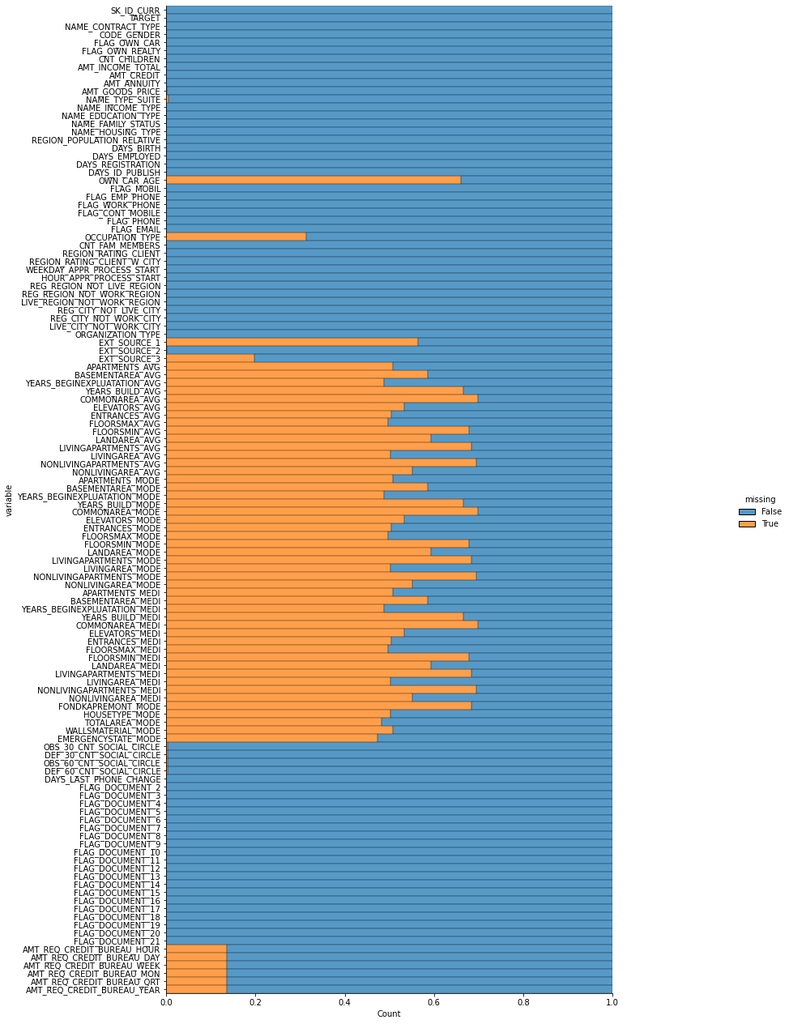

```python
  def plot_missing_data(df, x, y):
    g = sns.displot(
        data=datasets[df].isna().melt(value_name="missing"),
        y="variable",
        hue="missing",
        multiple="fill",
        aspect=1.25
    )
    g.fig.set_figwidth(x)
    g.fig.set_figheight(y)
plot_missing_data("application_train",18,20)
```

```python
percent = (datasets["application_test"].isnull().sum()/datasets["application_test"].isnull().count()*100).sort_values(ascending = False).round(2)
sum_missing = datasets["application_test"].isna().sum().sort_values(ascending = False)
missing_application_train_data  = pd.concat([percent, sum_missing], axis=1, keys=['Percent', "Test Missing Count"])
missing_application_train_data.head(20)
```

|  | Percent | Test Missing Count |
| --- | --- | --- |
| COMMONAREA_MEDI | 68.72 | 33495 |
| COMMONAREA_AVG | 68.72 | 33495 |
| COMMONAREA_MODE | 68.72 | 33495 |
| NONLIVINGAPARTMENTS_MODE | 68.41 | 33347 |
| NONLIVINGAPARTMENTS_MEDI | 68.41 | 33347 |
| NONLIVINGAPARTMENTS_AVG | 68.41 | 33347 |
| FONDKAPREMONT_MODE | 67.28 | 32797 |
| LIVINGAPARTMENTS_AVG | 67.25 | 32780 |
| LIVINGAPARTMENTS_MEDI | 67.25 | 32780 |
| LIVINGAPARTMENTS_MODE | 67.25 | 32780 |
| FLOORSMIN_MEDI | 66.61 | 32466 |
| FLOORSMIN_MODE | 66.61 | 32466 |
| FLOORSMIN_AVG | 66.61 | 32466 |
| OWN_CAR_AGE | 66.29 | 32312 |
| YEARS_BUILD_MEDI | 65.28 | 31818 |
| YEARS_BUILD_MODE | 65.28 | 31818 |
| YEARS_BUILD_AVG | 65.28 | 31818 |
| LANDAREA_AVG | 57.96 | 28254 |
| LANDAREA_MODE | 57.96 | 28254 |
| LANDAREA_MEDI | 57.96 | 28254 |

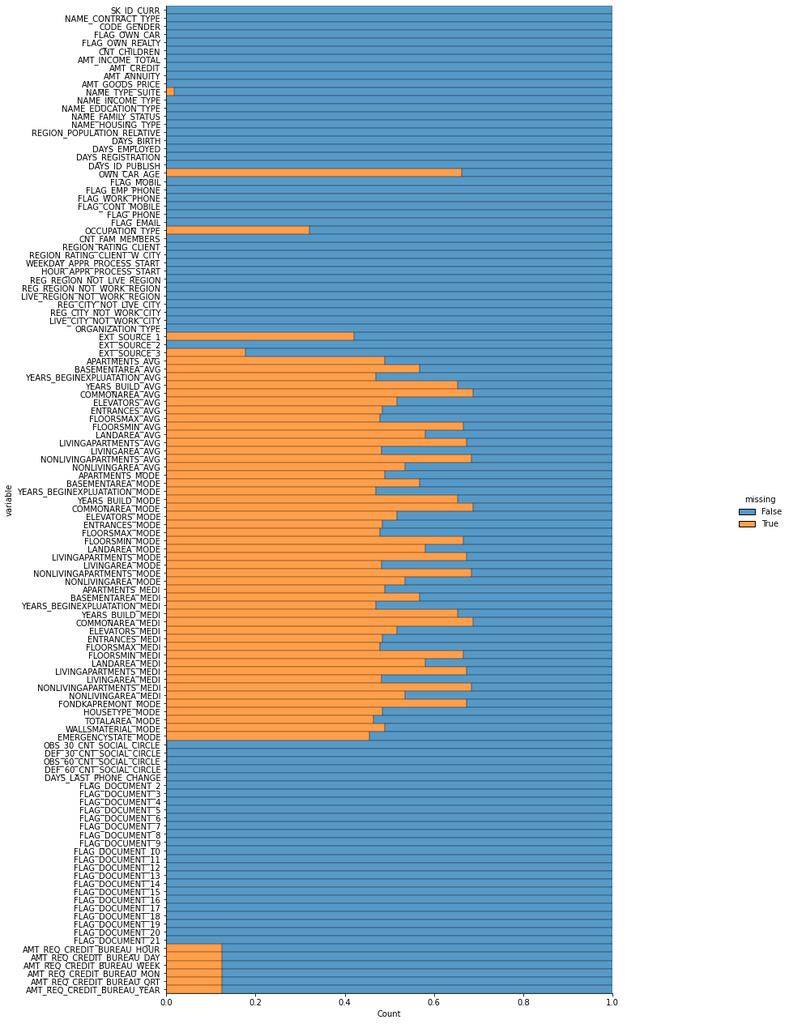

```python
plot_missing_data("application_test",18,20)
```

## Summary of Previous Applications Table

```python
datasets["previous_application"].info()
```

```
<class 'pandas.core.frame.DataFrame'>
RangeIndex: 1670214 entries, 0 to 1670213
Data columns (total 37 columns):
 #   Column                       Non-Null Count    Dtype
---  ------                       --------------    -----
 0   SK_ID_PREV                   1670214 non-null  int64
 1   SK_ID_CURR                   1670214 non-null  int64
 2   NAME_CONTRACT_TYPE           1670214 non-null  object
 3   AMT_ANNUITY                  1297979 non-null  float64
 4   AMT_APPLICATION              1670214 non-null  float64
 5   AMT_CREDIT                   1670213 non-null  float64
 6   AMT_DOWN_PAYMENT             774370 non-null   float64
 7   AMT_GOODS_PRICE              1284699 non-null  float64
 8   WEEKDAY_APPR_PROCESS_START   1670214 non-null  object
 9   HOUR_APPR_PROCESS_START      1670214 non-null  int64
```

[output cut: 29 more lines]

```python
datasets["previous_application"].describe()
```

|  | SK_ID_PREV | SK_ID_CURR | AMT_ANNUITY | AMT_APPLICATION | AMT_CREDIT | AMT_DOWN_PAYMENT | AMT_GOODS_PRICE | HOUR_APPR_PROCESS_START | NFLAG_LAST_APPL_IN_DAY | RATE_DOWN_PAYMENT | RATE_INTEREST_PRIMARY | RATE_INTEREST_PRIVILEGED | DAYS_DECISION | SELLERPLACE_AREA | CNT_PAYMENT | DAYS_FIRST_DRAWING | DAYS_FIRST_DUE | DAYS_LAST_DUE_1ST_VERSION | DAYS_LAST_DUE | DAYS_TERMINATION | NFLAG_INSURED_ON_APPROVAL |
| --- | --- | --- | --- | --- | --- | --- | --- | --- | --- | --- | --- | --- | --- | --- | --- | --- | --- | --- | --- | --- | --- |
| count | 1.670214e+06 | 1.670214e+06 | 1.297979e+06 | 1.670214e+06 | 1.670213e+06 | 7.743700e+05 | 1.284699e+06 | 1.670214e+06 | 1.670214e+06 | 774370.000000 | 5951.000000 | 5951.000000 | 1.670214e+06 | 1.670214e+06 | 1.297984e+06 | 997149.000000 | 997149.000000 | 997149.000000 | 997149.000000 | 997149.000000 | 997149.000000 |
| mean | 1.923089e+06 | 2.783572e+05 | 1.595512e+04 | 1.752339e+05 | 1.961140e+05 | 6.697402e+03 | 2.278473e+05 | 1.248418e+01 | 9.964675e-01 | 0.079637 | 0.188357 | 0.773503 | -8.806797e+02 | 3.139511e+02 | 1.605408e+01 | 342209.855039 | 13826.269337 | 33767.774054 | 76582.403064 | 81992.343838 | 0.332570 |
| std | 5.325980e+05 | 1.028148e+05 | 1.478214e+04 | 2.927798e+05 | 3.185746e+05 | 2.092150e+04 | 3.153966e+05 | 3.334028e+00 | 5.932963e-02 | 0.107823 | 0.087671 | 0.100879 | 7.790997e+02 | 7.127443e+03 | 1.456729e+01 | 88916.115834 | 72444.869708 | 106857.034789 | 149647.415123 | 153303.516729 | 0.471134 |
| min | 1.000001e+06 | 1.000010e+05 | 0.000000e+00 | 0.000000e+00 | 0.000000e+00 | -9.000000e-01 | 0.000000e+00 | 0.000000e+00 | 0.000000e+00 | -0.000015 | 0.034781 | 0.373150 | -2.922000e+03 | -1.000000e+00 | 0.000000e+00 | -2922.000000 | -2892.000000 | -2801.000000 | -2889.000000 | -2874.000000 | 0.000000 |
| 25% | 1.461857e+06 | 1.893290e+05 | 6.321780e+03 | 1.872000e+04 | 2.416050e+04 | 0.000000e+00 | 5.084100e+04 | 1.000000e+01 | 1.000000e+00 | 0.000000 | 0.160716 | 0.715645 | -1.300000e+03 | -1.000000e+00 | 6.000000e+00 | 365243.000000 | -1628.000000 | -1242.000000 | -1314.000000 | -1270.000000 | 0.000000 |
| 50% | 1.923110e+06 | 2.787145e+05 | 1.125000e+04 | 7.104600e+04 | 8.054100e+04 | 1.638000e+03 | 1.123200e+05 | 1.200000e+01 | 1.000000e+00 | 0.051605 | 0.189122 | 0.835095 | -5.810000e+02 | 3.000000e+00 | 1.200000e+01 | 365243.000000 | -831.000000 | -361.000000 | -537.000000 | -499.000000 | 0.000000 |
| 75% | 2.384280e+06 | 3.675140e+05 | 2.065842e+04 | 1.803600e+05 | 2.164185e+05 | 7.740000e+03 | 2.340000e+05 | 1.500000e+01 | 1.000000e+00 | 0.108909 | 0.193330 | 0.852537 | -2.800000e+02 | 8.200000e+01 | 2.400000e+01 | 365243.000000 | -411.000000 | 129.000000 | -74.000000 | -44.000000 | 1.000000 |
| max | 2.845382e+06 | 4.562550e+05 | 4.180581e+05 | 6.905160e+06 | 6.905160e+06 | 3.060045e+06 | 6.905160e+06 | 2.300000e+01 | 1.000000e+00 | 1.000000 | 1.000000 | 1.000000 | -1.000000e+00 | 4.000000e+06 | 8.400000e+01 | 365243.000000 | 365243.000000 | 365243.000000 | 365243.000000 | 365243.000000 | 1.000000 |

Observation:  
Most of the Days columns have negative values. This should be an anamoly

## Missing Values of Previous applications table

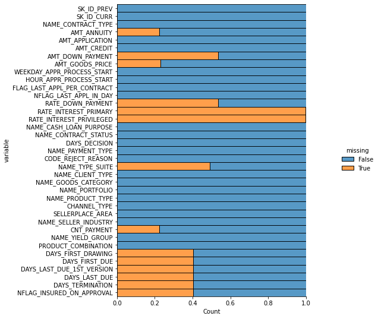

```python
plot_missing_data("previous_application",10,8)
```

## Summary of Bureau Table

```python
datasets["bureau"].info()
```

```
<class 'pandas.core.frame.DataFrame'>
RangeIndex: 1716428 entries, 0 to 1716427
Data columns (total 17 columns):
 #   Column                  Dtype
---  ------                  -----
 0   SK_ID_CURR              int64
 1   SK_ID_BUREAU            int64
 2   CREDIT_ACTIVE           object
 3   CREDIT_CURRENCY         object
 4   DAYS_CREDIT             int64
 5   CREDIT_DAY_OVERDUE      int64
 6   DAYS_CREDIT_ENDDATE     float64
 7   DAYS_ENDDATE_FACT       float64
 8   AMT_CREDIT_MAX_OVERDUE  float64
 9   CNT_CREDIT_PROLONG      int64
 10  AMT_CREDIT_SUM          float64
 11  AMT_CREDIT_SUM_DEBT     float64
 12  AMT_CREDIT_SUM_LIMIT    float64
 13  AMT_CREDIT_SUM_OVERDUE  float64
 14  CREDIT_TYPE             object
 15  DAYS_CREDIT_UPDATE      int64
 16  AMT_ANNUITY             float64
dtypes: float64(8), int64(6), object(3)
memory usage: 222.6+ MB
```

```python
datasets["bureau"].describe()
```

|  | SK_ID_CURR | SK_ID_BUREAU | DAYS_CREDIT | CREDIT_DAY_OVERDUE | DAYS_CREDIT_ENDDATE | DAYS_ENDDATE_FACT | AMT_CREDIT_MAX_OVERDUE | CNT_CREDIT_PROLONG | AMT_CREDIT_SUM | AMT_CREDIT_SUM_DEBT | AMT_CREDIT_SUM_LIMIT | AMT_CREDIT_SUM_OVERDUE | DAYS_CREDIT_UPDATE | AMT_ANNUITY |
| --- | --- | --- | --- | --- | --- | --- | --- | --- | --- | --- | --- | --- | --- | --- |
| count | 1.716428e+06 | 1.716428e+06 | 1.716428e+06 | 1.716428e+06 | 1.610875e+06 | 1.082775e+06 | 5.919400e+05 | 1.716428e+06 | 1.716415e+06 | 1.458759e+06 | 1.124648e+06 | 1.716428e+06 | 1.716428e+06 | 4.896370e+05 |
| mean | 2.782149e+05 | 5.924434e+06 | -1.142108e+03 | 8.181666e-01 | 5.105174e+02 | -1.017437e+03 | 3.825418e+03 | 6.410406e-03 | 3.549946e+05 | 1.370851e+05 | 6.229515e+03 | 3.791276e+01 | -5.937483e+02 | 1.571276e+04 |
| std | 1.029386e+05 | 5.322657e+05 | 7.951649e+02 | 3.654443e+01 | 4.994220e+03 | 7.140106e+02 | 2.060316e+05 | 9.622391e-02 | 1.149811e+06 | 6.774011e+05 | 4.503203e+04 | 5.937650e+03 | 7.207473e+02 | 3.258269e+05 |
| min | 1.000010e+05 | 5.000000e+06 | -2.922000e+03 | 0.000000e+00 | -4.206000e+04 | -4.202300e+04 | 0.000000e+00 | 0.000000e+00 | 0.000000e+00 | -4.705600e+06 | -5.864061e+05 | 0.000000e+00 | -4.194700e+04 | 0.000000e+00 |
| 25% | 1.888668e+05 | 5.463954e+06 | -1.666000e+03 | 0.000000e+00 | -1.138000e+03 | -1.489000e+03 | 0.000000e+00 | 0.000000e+00 | 5.130000e+04 | 0.000000e+00 | 0.000000e+00 | 0.000000e+00 | -9.080000e+02 | 0.000000e+00 |
| 50% | 2.780550e+05 | 5.926304e+06 | -9.870000e+02 | 0.000000e+00 | -3.300000e+02 | -8.970000e+02 | 0.000000e+00 | 0.000000e+00 | 1.255185e+05 | 0.000000e+00 | 0.000000e+00 | 0.000000e+00 | -3.950000e+02 | 0.000000e+00 |
| 75% | 3.674260e+05 | 6.385681e+06 | -4.740000e+02 | 0.000000e+00 | 4.740000e+02 | -4.250000e+02 | 0.000000e+00 | 0.000000e+00 | 3.150000e+05 | 4.015350e+04 | 0.000000e+00 | 0.000000e+00 | -3.300000e+01 | 1.350000e+04 |
| max | 4.562550e+05 | 6.843457e+06 | 0.000000e+00 | 2.792000e+03 | 3.119900e+04 | 0.000000e+00 | 1.159872e+08 | 9.000000e+00 | 5.850000e+08 | 1.701000e+08 | 4.705600e+06 | 3.756681e+06 | 3.720000e+02 | 1.184534e+08 |

## Missing values in Bureau

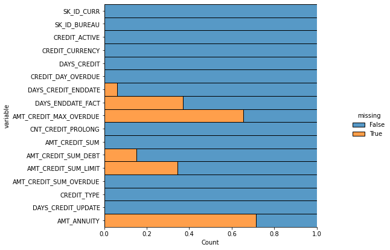

```python
plot_missing_data("bureau",10,6)
```

## Summary of Bureau Balance

```python
datasets["bureau_balance"].info()
```

```
<class 'pandas.core.frame.DataFrame'>
RangeIndex: 27299925 entries, 0 to 27299924
Data columns (total 3 columns):
 #   Column          Dtype
---  ------          -----
 0   SK_ID_BUREAU    int64
 1   MONTHS_BALANCE  int64
 2   STATUS          object
dtypes: int64(2), object(1)
memory usage: 624.8+ MB
```

```python
datasets["bureau_balance"].describe()
```

|  | SK_ID_BUREAU | MONTHS_BALANCE |
| --- | --- | --- |
| count | 2.729992e+07 | 2.729992e+07 |
| mean | 6.036297e+06 | -3.074169e+01 |
| std | 4.923489e+05 | 2.386451e+01 |
| min | 5.001709e+06 | -9.600000e+01 |
| 25% | 5.730933e+06 | -4.600000e+01 |
| 50% | 6.070821e+06 | -2.500000e+01 |
| 75% | 6.431951e+06 | -1.100000e+01 |
| max | 6.842888e+06 | 0.000000e+00 |

## Missing values in Bureau Balance

```python
percent = (datasets["bureau_balance"].isnull().sum()/datasets["bureau_balance"].isnull().count()*100).sort_values(ascending = False).round(2)
sum_missing = datasets["bureau_balance"].isna().sum().sort_values(ascending = False)
missing_application_train_data  = pd.concat([percent, sum_missing], axis=1, keys=['Percent', "bureau_balance Missing Count"])
missing_application_train_data.head(20)
```

|  | Percent | bureau_balance Missing Count |
| --- | --- | --- |
| STATUS | 0.0 | 0 |
| MONTHS_BALANCE | 0.0 | 0 |
| SK_ID_BUREAU | 0.0 | 0 |

## Summary of Credit Card Balance

```python
datasets["credit_card_balance"].info()
```

```
<class 'pandas.core.frame.DataFrame'>
RangeIndex: 3840312 entries, 0 to 3840311
Data columns (total 23 columns):
 #   Column                      Dtype
---  ------                      -----
 0   SK_ID_PREV                  int64
 1   SK_ID_CURR                  int64
 2   MONTHS_BALANCE              int64
 3   AMT_BALANCE                 float64
 4   AMT_CREDIT_LIMIT_ACTUAL     int64
 5   AMT_DRAWINGS_ATM_CURRENT    float64
 6   AMT_DRAWINGS_CURRENT        float64
 7   AMT_DRAWINGS_OTHER_CURRENT  float64
 8   AMT_DRAWINGS_POS_CURRENT    float64
 9   AMT_INST_MIN_REGULARITY     float64
 10  AMT_PAYMENT_CURRENT         float64
 11  AMT_PAYMENT_TOTAL_CURRENT   float64
 12  AMT_RECEIVABLE_PRINCIPAL    float64
 13  AMT_RECIVABLE               float64
 14  AMT_TOTAL_RECEIVABLE        float64
 15  CNT_DRAWINGS_ATM_CURRENT    float64
 16  CNT_DRAWINGS_CURRENT        int64
 17  CNT_DRAWINGS_OTHER_CURRENT  float64
 18  CNT_DRAWINGS_POS_CURRENT    float64
 19  CNT_INSTALMENT_MATURE_CUM   float64
 20  NAME_CONTRACT_STATUS        object
 21  SK_DPD                      int64
 22  SK_DPD_DEF                  int64
dtypes: float64(15), int64(7), object(1)
memory usage: 673.9+ MB
```

```python
datasets["credit_card_balance"].describe()
```

|  | SK_ID_PREV | SK_ID_CURR | MONTHS_BALANCE | AMT_BALANCE | AMT_CREDIT_LIMIT_ACTUAL | AMT_DRAWINGS_ATM_CURRENT | AMT_DRAWINGS_CURRENT | AMT_DRAWINGS_OTHER_CURRENT | AMT_DRAWINGS_POS_CURRENT | AMT_INST_MIN_REGULARITY | AMT_PAYMENT_CURRENT | AMT_PAYMENT_TOTAL_CURRENT | AMT_RECEIVABLE_PRINCIPAL | AMT_RECIVABLE | AMT_TOTAL_RECEIVABLE | CNT_DRAWINGS_ATM_CURRENT | CNT_DRAWINGS_CURRENT | CNT_DRAWINGS_OTHER_CURRENT | CNT_DRAWINGS_POS_CURRENT | CNT_INSTALMENT_MATURE_CUM | SK_DPD | SK_DPD_DEF |
| --- | --- | --- | --- | --- | --- | --- | --- | --- | --- | --- | --- | --- | --- | --- | --- | --- | --- | --- | --- | --- | --- | --- |
| count | 3.840312e+06 | 3.840312e+06 | 3.840312e+06 | 3.840312e+06 | 3.840312e+06 | 3.090496e+06 | 3.840312e+06 | 3.090496e+06 | 3.090496e+06 | 3.535076e+06 | 3.072324e+06 | 3.840312e+06 | 3.840312e+06 | 3.840312e+06 | 3.840312e+06 | 3.090496e+06 | 3.840312e+06 | 3.090496e+06 | 3.090496e+06 | 3.535076e+06 | 3.840312e+06 | 3.840312e+06 |
| mean | 1.904504e+06 | 2.783242e+05 | -3.452192e+01 | 5.830016e+04 | 1.538080e+05 | 5.961325e+03 | 7.433388e+03 | 2.881696e+02 | 2.968805e+03 | 3.540204e+03 | 1.028054e+04 | 7.588857e+03 | 5.596588e+04 | 5.808881e+04 | 5.809829e+04 | 3.094490e-01 | 7.031439e-01 | 4.812496e-03 | 5.594791e-01 | 2.082508e+01 | 9.283667e+00 | 3.316220e-01 |
| std | 5.364695e+05 | 1.027045e+05 | 2.666775e+01 | 1.063070e+05 | 1.651457e+05 | 2.822569e+04 | 3.384608e+04 | 8.201989e+03 | 2.079689e+04 | 5.600154e+03 | 3.607808e+04 | 3.200599e+04 | 1.025336e+05 | 1.059654e+05 | 1.059718e+05 | 1.100401e+00 | 3.190347e+00 | 8.263861e-02 | 3.240649e+00 | 2.005149e+01 | 9.751570e+01 | 2.147923e+01 |
| min | 1.000018e+06 | 1.000060e+05 | -9.600000e+01 | -4.202502e+05 | 0.000000e+00 | -6.827310e+03 | -6.211620e+03 | 0.000000e+00 | 0.000000e+00 | 0.000000e+00 | 0.000000e+00 | 0.000000e+00 | -4.233058e+05 | -4.202502e+05 | -4.202502e+05 | 0.000000e+00 | 0.000000e+00 | 0.000000e+00 | 0.000000e+00 | 0.000000e+00 | 0.000000e+00 | 0.000000e+00 |
| 25% | 1.434385e+06 | 1.895170e+05 | -5.500000e+01 | 0.000000e+00 | 4.500000e+04 | 0.000000e+00 | 0.000000e+00 | 0.000000e+00 | 0.000000e+00 | 0.000000e+00 | 1.523700e+02 | 0.000000e+00 | 0.000000e+00 | 0.000000e+00 | 0.000000e+00 | 0.000000e+00 | 0.000000e+00 | 0.000000e+00 | 0.000000e+00 | 4.000000e+00 | 0.000000e+00 | 0.000000e+00 |
| 50% | 1.897122e+06 | 2.783960e+05 | -2.800000e+01 | 0.000000e+00 | 1.125000e+05 | 0.000000e+00 | 0.000000e+00 | 0.000000e+00 | 0.000000e+00 | 0.000000e+00 | 2.702700e+03 | 0.000000e+00 | 0.000000e+00 | 0.000000e+00 | 0.000000e+00 | 0.000000e+00 | 0.000000e+00 | 0.000000e+00 | 0.000000e+00 | 1.500000e+01 | 0.000000e+00 | 0.000000e+00 |
| 75% | 2.369328e+06 | 3.675800e+05 | -1.100000e+01 | 8.904669e+04 | 1.800000e+05 | 0.000000e+00 | 0.000000e+00 | 0.000000e+00 | 0.000000e+00 | 6.633911e+03 | 9.000000e+03 | 6.750000e+03 | 8.535924e+04 | 8.889949e+04 | 8.891451e+04 | 0.000000e+00 | 0.000000e+00 | 0.000000e+00 | 0.000000e+00 | 3.200000e+01 | 0.000000e+00 | 0.000000e+00 |
| max | 2.843496e+06 | 4.562500e+05 | -1.000000e+00 | 1.505902e+06 | 1.350000e+06 | 2.115000e+06 | 2.287098e+06 | 1.529847e+06 | 2.239274e+06 | 2.028820e+05 | 4.289207e+06 | 4.278316e+06 | 1.472317e+06 | 1.493338e+06 | 1.493338e+06 | 5.100000e+01 | 1.650000e+02 | 1.200000e+01 | 1.650000e+02 | 1.200000e+02 | 3.260000e+03 | 3.260000e+03 |

## Missing values in Credit Card Balance

```python
percent = (datasets["credit_card_balance"].isnull().sum()/datasets["credit_card_balance"].isnull().count()*100).sort_values(ascending = False).round(2)
sum_missing = datasets["credit_card_balance"].isna().sum().sort_values(ascending = False)
missing_application_train_data  = pd.concat([percent, sum_missing], axis=1, keys=['Percent', "credit_card_balance Missing Count"])
missing_application_train_data.head(20)
```

|  | Percent | credit_card_balance Missing Count |
| --- | --- | --- |
| AMT_PAYMENT_CURRENT | 20.00 | 767988 |
| AMT_DRAWINGS_OTHER_CURRENT | 19.52 | 749816 |
| CNT_DRAWINGS_POS_CURRENT | 19.52 | 749816 |
| CNT_DRAWINGS_OTHER_CURRENT | 19.52 | 749816 |
| CNT_DRAWINGS_ATM_CURRENT | 19.52 | 749816 |
| AMT_DRAWINGS_ATM_CURRENT | 19.52 | 749816 |
| AMT_DRAWINGS_POS_CURRENT | 19.52 | 749816 |
| CNT_INSTALMENT_MATURE_CUM | 7.95 | 305236 |
| AMT_INST_MIN_REGULARITY | 7.95 | 305236 |
| SK_DPD_DEF | 0.00 | 0 |
| SK_ID_CURR | 0.00 | 0 |
| MONTHS_BALANCE | 0.00 | 0 |
| AMT_BALANCE | 0.00 | 0 |
| AMT_CREDIT_LIMIT_ACTUAL | 0.00 | 0 |
| AMT_DRAWINGS_CURRENT | 0.00 | 0 |
| AMT_PAYMENT_TOTAL_CURRENT | 0.00 | 0 |
| SK_DPD | 0.00 | 0 |
| AMT_RECEIVABLE_PRINCIPAL | 0.00 | 0 |
| AMT_RECIVABLE | 0.00 | 0 |
| AMT_TOTAL_RECEIVABLE | 0.00 | 0 |

## Summary of Installments payments

```python
datasets["installments_payments"].info()
```

```
<class 'pandas.core.frame.DataFrame'>
RangeIndex: 13605401 entries, 0 to 13605400
Data columns (total 8 columns):
 #   Column                  Dtype
---  ------                  -----
 0   SK_ID_PREV              int64
 1   SK_ID_CURR              int64
 2   NUM_INSTALMENT_VERSION  float64
 3   NUM_INSTALMENT_NUMBER   int64
 4   DAYS_INSTALMENT         float64
 5   DAYS_ENTRY_PAYMENT      float64
 6   AMT_INSTALMENT          float64
 7   AMT_PAYMENT             float64
dtypes: float64(5), int64(3)
memory usage: 830.4 MB
```

```python
datasets["installments_payments"].describe()
```

|  | SK_ID_PREV | SK_ID_CURR | NUM_INSTALMENT_VERSION | NUM_INSTALMENT_NUMBER | DAYS_INSTALMENT | DAYS_ENTRY_PAYMENT | AMT_INSTALMENT | AMT_PAYMENT |
| --- | --- | --- | --- | --- | --- | --- | --- | --- |
| count | 1.360540e+07 | 1.360540e+07 | 1.360540e+07 | 1.360540e+07 | 1.360540e+07 | 1.360250e+07 | 1.360540e+07 | 1.360250e+07 |
| mean | 1.903365e+06 | 2.784449e+05 | 8.566373e-01 | 1.887090e+01 | -1.042270e+03 | -1.051114e+03 | 1.705091e+04 | 1.723822e+04 |
| std | 5.362029e+05 | 1.027183e+05 | 1.035216e+00 | 2.666407e+01 | 8.009463e+02 | 8.005859e+02 | 5.057025e+04 | 5.473578e+04 |
| min | 1.000001e+06 | 1.000010e+05 | 0.000000e+00 | 1.000000e+00 | -2.922000e+03 | -4.921000e+03 | 0.000000e+00 | 0.000000e+00 |
| 25% | 1.434191e+06 | 1.896390e+05 | 0.000000e+00 | 4.000000e+00 | -1.654000e+03 | -1.662000e+03 | 4.226085e+03 | 3.398265e+03 |
| 50% | 1.896520e+06 | 2.786850e+05 | 1.000000e+00 | 8.000000e+00 | -8.180000e+02 | -8.270000e+02 | 8.884080e+03 | 8.125515e+03 |
| 75% | 2.369094e+06 | 3.675300e+05 | 1.000000e+00 | 1.900000e+01 | -3.610000e+02 | -3.700000e+02 | 1.671021e+04 | 1.610842e+04 |
| max | 2.843499e+06 | 4.562550e+05 | 1.780000e+02 | 2.770000e+02 | -1.000000e+00 | -1.000000e+00 | 3.771488e+06 | 3.771488e+06 |

## Missing values in Installments payments

```python
# plot_missing_data("installments_payments",10,8)
percent = (datasets["installments_payments"].isnull().sum()/datasets["installments_payments"].isnull().count()*100).sort_values(ascending = False).round(2)
sum_missing = datasets["installments_payments"].isna().sum().sort_values(ascending = False)
missing_application_train_data  = pd.concat([percent, sum_missing], axis=1, keys=['Percent', "Installment payments Missing Count"])
missing_application_train_data.head(20)
```

|  | Percent | Installment payments Missing Count |
| --- | --- | --- |
| AMT_PAYMENT | 0.02 | 2905 |
| DAYS_ENTRY_PAYMENT | 0.02 | 2905 |
| AMT_INSTALMENT | 0.00 | 0 |
| DAYS_INSTALMENT | 0.00 | 0 |
| NUM_INSTALMENT_NUMBER | 0.00 | 0 |
| NUM_INSTALMENT_VERSION | 0.00 | 0 |
| SK_ID_CURR | 0.00 | 0 |
| SK_ID_PREV | 0.00 | 0 |

## Summary of POS CASH balance

```python
datasets["POS_CASH_balance"].info()
```

```
<class 'pandas.core.frame.DataFrame'>
RangeIndex: 10001358 entries, 0 to 10001357
Data columns (total 8 columns):
 #   Column                 Dtype
---  ------                 -----
 0   SK_ID_PREV             int64
 1   SK_ID_CURR             int64
 2   MONTHS_BALANCE         int64
 3   CNT_INSTALMENT         float64
 4   CNT_INSTALMENT_FUTURE  float64
 5   NAME_CONTRACT_STATUS   object
 6   SK_DPD                 int64
 7   SK_DPD_DEF             int64
dtypes: float64(2), int64(5), object(1)
memory usage: 610.4+ MB
```

```python
datasets["POS_CASH_balance"].describe()
```

|  | SK_ID_PREV | SK_ID_CURR | MONTHS_BALANCE | CNT_INSTALMENT | CNT_INSTALMENT_FUTURE | SK_DPD | SK_DPD_DEF |
| --- | --- | --- | --- | --- | --- | --- | --- |
| count | 1.000136e+07 | 1.000136e+07 | 1.000136e+07 | 9.975287e+06 | 9.975271e+06 | 1.000136e+07 | 1.000136e+07 |
| mean | 1.903217e+06 | 2.784039e+05 | -3.501259e+01 | 1.708965e+01 | 1.048384e+01 | 1.160693e+01 | 6.544684e-01 |
| std | 5.358465e+05 | 1.027637e+05 | 2.606657e+01 | 1.199506e+01 | 1.110906e+01 | 1.327140e+02 | 3.276249e+01 |
| min | 1.000001e+06 | 1.000010e+05 | -9.600000e+01 | 1.000000e+00 | 0.000000e+00 | 0.000000e+00 | 0.000000e+00 |
| 25% | 1.434405e+06 | 1.895500e+05 | -5.400000e+01 | 1.000000e+01 | 3.000000e+00 | 0.000000e+00 | 0.000000e+00 |
| 50% | 1.896565e+06 | 2.786540e+05 | -2.800000e+01 | 1.200000e+01 | 7.000000e+00 | 0.000000e+00 | 0.000000e+00 |
| 75% | 2.368963e+06 | 3.674290e+05 | -1.300000e+01 | 2.400000e+01 | 1.400000e+01 | 0.000000e+00 | 0.000000e+00 |
| max | 2.843499e+06 | 4.562550e+05 | -1.000000e+00 | 9.200000e+01 | 8.500000e+01 | 4.231000e+03 | 3.595000e+03 |

## Missing values in POS CASH balance

```python
# plot_missing_data("POS_CASH_balance",5,4)
percent = (datasets["POS_CASH_balance"].isnull().sum()/datasets["POS_CASH_balance"].isnull().count()*100).sort_values(ascending = False).round(2)
sum_missing = datasets["POS_CASH_balance"].isna().sum().sort_values(ascending = False)
missing_application_train_data  = pd.concat([percent, sum_missing], axis=1, keys=['Percent', "POS_CASH_balance Missing Count"])
missing_application_train_data.head(20)
```

|  | Percent | POS_CASH_balance Missing Count |
| --- | --- | --- |
| CNT_INSTALMENT_FUTURE | 0.26 | 26087 |
| CNT_INSTALMENT | 0.26 | 26071 |
| SK_DPD_DEF | 0.00 | 0 |
| SK_DPD | 0.00 | 0 |
| NAME_CONTRACT_STATUS | 0.00 | 0 |
| MONTHS_BALANCE | 0.00 | 0 |
| SK_ID_CURR | 0.00 | 0 |
| SK_ID_PREV | 0.00 | 0 |

## Distribution of Repaid and Unpaid Loan

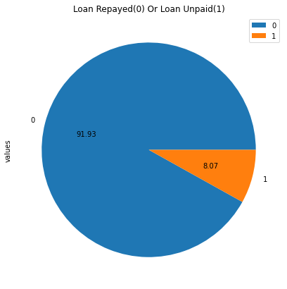

```python
%matplotlib inline
application_train = datasets["application_train"]
temp = application_train["TARGET"].value_counts()
df = pd.DataFrame({'labels': temp.index,
                   'values': temp.values
                  })
df.plot.pie(y='values',title="Loan Repayed(0) Or Loan Unpaid(1)", figsize=(7,7), autopct='%.2f')
```

Observation:  
As we can see that the data is imbalanced, the proportion of applicants who have unpaid the loans is very less

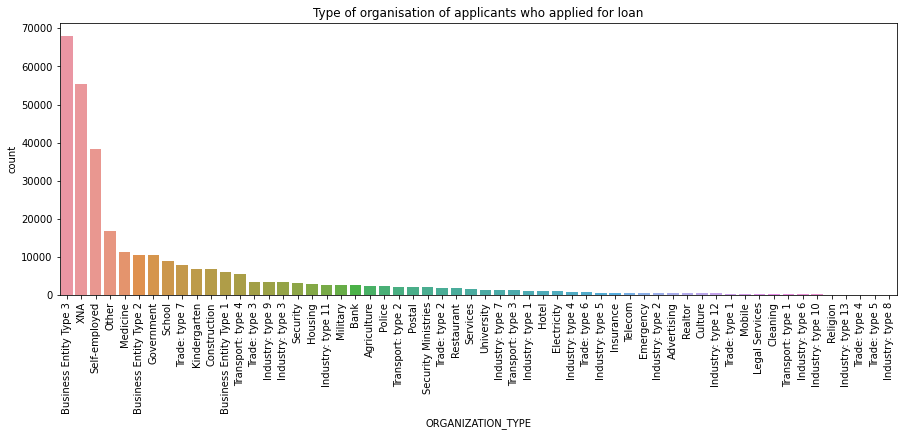

```python
plt.figure(figsize=(15,5))
sns.countplot(x='ORGANIZATION_TYPE', data=datasets["application_train"], order = datasets["application_train"]['ORGANIZATION_TYPE'].value_counts().index);
plt.title('Type of organisation of applicants who applied for loan');
plt.xticks(rotation=90);
```

**Types of Organizations who applied for loan :**

- Business Entity Type 3 - Approx. 68 K
- XNA - Approx. 55 K
- Self employed - Approx. 38 K

## Applicants Age

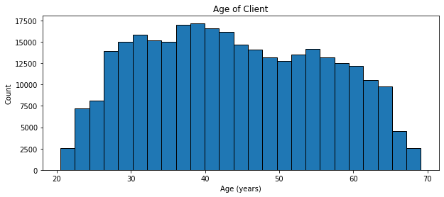

```python
plt.figure(figsize=(10,4))
plt.hist(datasets["application_train"]['DAYS_BIRTH'] / -365, edgecolor = 'k', bins = 25)
plt.title('Age of Client'); plt.xlabel('Age (years)'); plt.ylabel('Count');
```

### Applicants Age category with respect to Loan Repaid target variable

```python
datasets["application_train"]['age'] = (np.round(datasets["application_train"]['DAYS_BIRTH']/-365))

datasets["application_train"].loc[(datasets["application_train"]['age'] > 20) & (datasets["application_train"]
                                                                                ['age'] <= 30), 'age_cat'] = '20-30'
datasets["application_train"].loc[(datasets["application_train"]['age'] > 30) & (datasets["application_train"]
                                                                                ['age'] <= 40), 'age_cat'] = '30-40'
datasets["application_train"].loc[(datasets["application_train"]['age'] > 40) & (datasets["application_train"]
                                                                                ['age'] <= 50), 'age_cat'] = '40-50'
datasets["application_train"].loc[(datasets["application_train"]['age'] > 50) & (datasets["application_train"]
                                                                                ['age'] <= 60), 'age_cat'] = '50-60'
datasets["application_train"].loc[(datasets["application_train"]['age'] > 60) & (datasets["application_train"]
                                                                                ['age'] <= 70), 'age_cat'] = '60-70'
datasets["application_train"].head()
```

|  | SK_ID_CURR | TARGET | NAME_CONTRACT_TYPE | CODE_GENDER | FLAG_OWN_CAR | FLAG_OWN_REALTY | CNT_CHILDREN | AMT_INCOME_TOTAL | AMT_CREDIT | AMT_ANNUITY | AMT_GOODS_PRICE | NAME_TYPE_SUITE | NAME_INCOME_TYPE | NAME_EDUCATION_TYPE | NAME_FAMILY_STATUS | NAME_HOUSING_TYPE | REGION_POPULATION_RELATIVE | DAYS_BIRTH | DAYS_EMPLOYED | DAYS_REGISTRATION | DAYS_ID_PUBLISH | OWN_CAR_AGE | FLAG_MOBIL | FLAG_EMP_PHONE | FLAG_WORK_PHONE | FLAG_CONT_MOBILE | FLAG_PHONE | FLAG_EMAIL | OCCUPATION_TYPE | … |
| --- | --- | --- | --- | --- | --- | --- | --- | --- | --- | --- | --- | --- | --- | --- | --- | --- | --- | --- | --- | --- | --- | --- | --- | --- | --- | --- | --- | --- | --- | --- |
| 0 | 100002 | 1 | Cash loans | M | N | Y | 0 | 202500.0 | 406597.5 | 24700.5 | 351000.0 | Unaccompanied | Working | Secondary / secondary special | Single / not married | House / apartment | 0.018801 | -9461 | -637 | -3648.0 | -2120 | NaN | 1 | 1 | 0 | 1 | 1 | 0 | Laborers | … |
| 1 | 100003 | 0 | Cash loans | F | N | N | 0 | 270000.0 | 1293502.5 | 35698.5 | 1129500.0 | Family | State servant | Higher education | Married | House / apartment | 0.003541 | -16765 | -1188 | -1186.0 | -291 | NaN | 1 | 1 | 0 | 1 | 1 | 0 | Core staff | … |
| 2 | 100004 | 0 | Revolving loans | M | Y | Y | 0 | 67500.0 | 135000.0 | 6750.0 | 135000.0 | Unaccompanied | Working | Secondary / secondary special | Single / not married | House / apartment | 0.010032 | -19046 | -225 | -4260.0 | -2531 | 26.0 | 1 | 1 | 1 | 1 | 1 | 0 | Laborers | … |
| 3 | 100006 | 0 | Cash loans | F | N | Y | 0 | 135000.0 | 312682.5 | 29686.5 | 297000.0 | Unaccompanied | Working | Secondary / secondary special | Civil marriage | House / apartment | 0.008019 | -19005 | -3039 | -9833.0 | -2437 | NaN | 1 | 1 | 0 | 1 | 0 | 0 | Laborers | … |
| 4 | 100007 | 0 | Cash loans | M | N | Y | 0 | 121500.0 | 513000.0 | 21865.5 | 513000.0 | Unaccompanied | Working | Secondary / secondary special | Single / not married | House / apartment | 0.028663 | -19932 | -3038 | -4311.0 | -3458 | NaN | 1 | 1 | 0 | 1 | 0 | 0 | Core staff | … |

5 rows × 124 columns

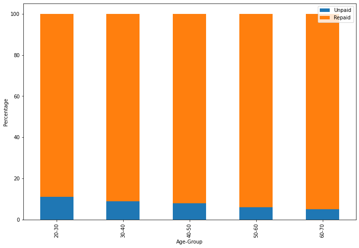

```python
plotdata = pd.DataFrame({
    "Unpaid":np.round((datasets["application_train"].groupby(['age_cat'])['TARGET'].sum()/datasets["application_train"].groupby(['age_cat'])['TARGET'].count())*100),
    "Repaid":np.round(((datasets["application_train"].groupby(['age_cat'])['TARGET'].count() - datasets["application_train"].groupby(['age_cat'])['TARGET'].sum())/datasets["application_train"].groupby(['age_cat'])['TARGET'].count())*100),
    },
    index=['20-30','30-40','40-50','50-60','60-70']
)
ax = plotdata.plot(kind="bar", stacked=True, xlabel="Age-Group", ylabel="Percentage", figsize=(12,8))
for c in ax.containers:

    labels = [v.get_height() if v.get_height() > 0 else '' for v in c]
    # ax.bar_label(c, labels=labels, label_type='center')
```

Observation:  
People of higher age groups are more likely to repay the loans than people of lower age group.

```python
datasets["application_train"].drop(columns=['age','age_cat'], axis=1, inplace=True)
```

[output not shown]

## Applicants occupations

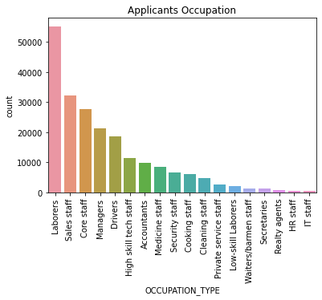

```python
sns.countplot(x='OCCUPATION_TYPE', data=datasets["application_train"], order = datasets["application_train"]['OCCUPATION_TYPE'].value_counts().index);

plt.title('Applicants Occupation');
plt.xticks(rotation=90);
```

Observations:  
Most of the loan applicants are Laborers, Sale's Staff and Core Staff.

## Pair-based Evaluation of Categorical variables of Train dataset with Target variable

[figure not shown]

```python
df = datasets["application_train"].copy()
df['TARGET'].replace(0, "Unpaid", inplace=True)
df['TARGET'].replace(1, "Repaid", inplace=True)

categorical_col = []

for col in df:
    if df[col].dtype == 'object':
        categorical_col.append(col)

plot_x = int(len(categorical_col)/2)
fig, ax = plt.subplots(plot_x, 2, figsize=(20, 50))

num = 0
for i in range(0, 9):
    for j in range(0,2):
        tst = sns.countplot(x=categorical_col[num],
                           data=df, hue='TARGET', ax=ax[i][j])
        tst.set_title(f"Distribution of the {categorical_col[num]}  Variable.")
        tst.set_xticklabels(tst.get_xticklabels(), rotation=90)
        plt.subplots_adjust(left=None, bottom=None, right=None,
                    top=None, wspace=None, hspace=0.45)
        num = num + 1
        plt.tight_layout()
```

## Correlation of numeric variables with the Target variable

```python
correlations = np.abs(datasets["application_train"].corr()['TARGET']).sort_values(ascending=False)
print('High value Correlations:\n', correlations.head(11))
```

```
High value Correlations:
 TARGET                         1.000000
EXT_SOURCE_3                   0.178919
EXT_SOURCE_2                   0.160472
EXT_SOURCE_1                   0.155317
DAYS_BIRTH                     0.078239
REGION_RATING_CLIENT_W_CITY    0.060893
REGION_RATING_CLIENT           0.058899
DAYS_LAST_PHONE_CHANGE         0.055218
DAYS_ID_PUBLISH                0.051457
REG_CITY_NOT_WORK_CITY         0.050994
FLAG_EMP_PHONE                 0.045982
Name: TARGET, dtype: float64
```

```python
from pandas.plotting import scatter_matrix
#We can take the top 10 features
top_corr_features = ["TARGET", "REGION_RATING_CLIENT","REGION_RATING_CLIENT_W_CITY","DAYS_LAST_PHONE_CHANGE",
               "DAYS_BIRTH", "EXT_SOURCE_1", "EXT_SOURCE_2", "EXT_SOURCE_3", "DAYS_ID_PUBLISH","REG_CITY_NOT_WORK_CITY"]
# scatter_matrix(datasets["application_train"][top_corr_features], figsize=(12, 8));
df = datasets["application_train"].copy()
df2 = df[top_corr_features]
corr = df2.corr()
corr.style.background_gradient(cmap='PuBu').set_precision(2)
```

|  | TARGET | REGION_RATING_CLIENT | REGION_RATING_CLIENT_W_CITY | DAYS_LAST_PHONE_CHANGE | DAYS_BIRTH | EXT_SOURCE_1 | EXT_SOURCE_2 | EXT_SOURCE_3 | DAYS_ID_PUBLISH | REG_CITY_NOT_WORK_CITY |
| --- | --- | --- | --- | --- | --- | --- | --- | --- | --- | --- |
| TARGET | 1.00 | 0.06 | 0.06 | 0.06 | 0.08 | -0.16 | -0.16 | -0.18 | 0.05 | 0.05 |
| REGION_RATING_CLIENT | 0.06 | 1.00 | 0.95 | 0.03 | 0.01 | -0.12 | -0.29 | -0.01 | -0.01 | 0.01 |
| REGION_RATING_CLIENT_W_CITY | 0.06 | 0.95 | 1.00 | 0.03 | 0.01 | -0.12 | -0.29 | -0.01 | -0.01 | 0.03 |
| DAYS_LAST_PHONE_CHANGE | 0.06 | 0.03 | 0.03 | 1.00 | 0.08 | -0.13 | -0.20 | -0.08 | 0.09 | 0.05 |
| DAYS_BIRTH | 0.08 | 0.01 | 0.01 | 0.08 | 1.00 | -0.60 | -0.09 | -0.21 | 0.27 | 0.24 |
| EXT_SOURCE_1 | -0.16 | -0.12 | -0.12 | -0.13 | -0.60 | 1.00 | 0.21 | 0.19 | -0.13 | -0.19 |
| EXT_SOURCE_2 | -0.16 | -0.29 | -0.29 | -0.20 | -0.09 | 0.21 | 1.00 | 0.11 | -0.05 | -0.08 |
| EXT_SOURCE_3 | -0.18 | -0.01 | -0.01 | -0.08 | -0.21 | 0.19 | 0.11 | 1.00 | -0.13 | -0.08 |
| DAYS_ID_PUBLISH | 0.05 | -0.01 | -0.01 | 0.09 | 0.27 | -0.13 | -0.05 | -0.13 | 1.00 | 0.10 |
| REG_CITY_NOT_WORK_CITY | 0.05 | 0.01 | 0.03 | 0.05 | 0.24 | -0.19 | -0.08 | -0.08 | 0.10 | 1.00 |

- Ext_source_1, Ext_source_2, Ext_source_3 and DAYS_BIRTH (i.e. Age) are the most highly correlated with the Loan Repaid target variable

### Histogram of Number of previous applications for an ID

```python
appsDF = datasets["previous_application"]
```

```python
sum(appsDF['SK_ID_CURR'].value_counts()==1)
```

```
60458
```

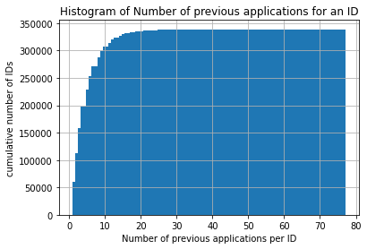

```python
plt.hist(appsDF['SK_ID_CURR'].value_counts(), cumulative =True, bins = 100);
plt.grid()
plt.ylabel('cumulative number of IDs')
plt.xlabel('Number of previous applications per ID')
plt.title('Histogram of Number of previous applications for an ID')
```

##### **Can we differentiate applications by low, medium and high previous apps?**

[output not shown]

```python
apps_all = appsDF['SK_ID_CURR'].nunique()
apps_5plus = appsDF['SK_ID_CURR'].value_counts()>=5
apps_40plus = appsDF['SK_ID_CURR'].value_counts()>=40
print('Percentage with 10 or more previous apps:', np.round(100.*(sum(apps_5plus)/apps_all),5))
print('Percentage with 40 or more previous apps:', np.round(100.*(sum(apps_40plus)/apps_all),5))
```

[output not shown]

# Feature Engineering

## One Hot Encoding for Categorical variables

```python
def one_hot_encoder(df):
    original_columns = list(df.columns)
    categorical_columns = [col for col in df.columns if df[col].dtype == 'object']
    df = pd.get_dummies(df, columns= categorical_columns, dummy_na= False)
    new_columns = [c for c in df.columns if c not in original_columns]
    return df, new_columns
```

## Feature Aggregator for Numerical variables

```python
# Create aggregate features (via pipeline)
class FeaturesAggregater(BaseEstimator, TransformerMixin):
    def __init__(self, dataset_name=None, dataset=None, features=None): # no *args or **kargs
        self.features = features
        self.dataset_name = dataset_name
        self.dataset = dataset
        self.agg_ops = ["min", "max", "mean", "sum"]

    def fit(self, X, y=None):
        return self

    def transform(self, X, y=None):
        result = X.groupby(["SK_ID_CURR"], as_index=False).agg({f"{f}":self.agg_ops for f in self.features})
        result.columns = result.columns.map('_'.join)
        return result


class BureauBalanceFeaturesAggregater(BaseEstimator, TransformerMixin):
    def __init__(self, dataset_name=None, dataset=None,features=None): # no *args or **kargs
        self.features = features
        self.dataset_name = dataset_name
        self.dataset = dataset
        self.agg_ops = ["min", "max", "mean", "sum"]

    def fit(self, X, y=None):
        return self

    def transform(self, X, y=None):
        result = X.groupby(["SK_ID_BUREAU"], as_index=False).agg({f"{f}":self.agg_ops for f in self.features})
        result.columns = result.columns.map('_'.join)
        result.rename(columns={self.dataset_name + '_' +'SK_ID_BUREAU_':'SK_ID_BUREAU'}, inplace=True)
        result.columns = pd.Index(['BUR_BAL_' + e for e in result.columns.tolist()])
        return result
```

## Add Features

```python
 def bureau_add_features():
    bureau['BUREAU_CREDIT_TO_ANNUITY_RATIO'] = bureau['BUREAU_AMT_CREDIT_SUM'] / bureau['BUREAU_AMT_ANNUITY']
    bureau['BUREAU_CREDIT_TO_INCOME_RATIO'] = bureau['BUREAU_AMT_CREDIT_SUM_mean'] / datasets['application_train']['AMT_INCOME_TOTAL']
    bureau['BUREAU_CREDIT_DURATION'] = -bureau['BUREAU_DAYS_CREDIT'] + bureau['BUREAU_DAYS_CREDIT_ENDDATE']
    bureau['BUREAU_ENDDATE_DIF'] = bureau['BUREAU_DAYS_CREDIT_ENDDATE'] - bureau['BUREAU_DAYS_ENDDATE_FACT']
    bureau['BUREAU_DEBT_RATIO'] = bureau['BUREAU_AMT_CREDIT_SUM'] / bureau['BUREAU_AMT_CREDIT_SUM_DEBT']
    # bureau.rename(columns={'AMT_ANNUITY':'BUREAU_AMT_ANNUITY'}, inplace=True)
    return bureau

def prevApps_add_features():
    prevApps['PREVAPP_APPLICATION_CREDIT_DIFF'] = prevApps['PREVAPP_AMT_APPLICATION'] - prevApps['PREVAPP_AMT_CREDIT']
    prevApps['PREVAPP_APPLICATION_CREDIT_RATIO'] = prevApps['PREVAPP_AMT_APPLICATION'] / prevApps['PREVAPP_AMT_CREDIT']
    prevApps['PREVAPP_CREDIT_TO_ANNUITY_RATIO'] = prevApps['PREVAPP_AMT_CREDIT']/prevApps['PREVAPP_AMT_ANNUITY']
    prevApps['PREVAPP_DOWN_PAYMENT_TO_CREDIT'] = prevApps['PREVAPP_AMT_DOWN_PAYMENT'] / prevApps['PREVAPP_AMT_CREDIT']
    return prevApps

def cc_bal_add_features():
    cc_bal['CC_BAL_LIMIT_USE'] = cc_bal['CC_BAL_AMT_BALANCE'] / cc_bal['CC_BAL_AMT_CREDIT_LIMIT_ACTUAL']
    cc_bal['CC_BAL_DRAWING_LIMIT_RATIO'] = cc_bal['CC_BAL_AMT_DRAWINGS_ATM_CURRENT'] / cc_bal['CC_BAL_AMT_CREDIT_LIMIT_ACTUAL']
    return cc_bal

def installments_pmnts_add_features():
    installments_pmnts['INSTLMNT_PAID_OVER_AMOUNT'] = installments_pmnts['INSTLMNT_AMT_PAYMENT'] - installments_pmnts['INSTLMNT_AMT_INSTALMENT']
    return installments_pmnts

def app_train_add_features(df):
    df['CREDIT_TO_ANNUITY_RATIO'] = df['AMT_CREDIT'] / df['AMT_ANNUITY']
    df['CREDIT_TO_GOODS_RATIO'] = df['AMT_CREDIT'] / df['AMT_GOODS_PRICE']
    # Income ratios
    df['ANNUITY_TO_INCOME_RATIO'] = df['AMT_ANNUITY'] / df['AMT_INCOME_TOTAL']
    df['CREDIT_TO_INCOME_RATIO'] = df['AMT_CREDIT'] / df['AMT_INCOME_TOTAL']
    df['INCOME_TO_EMPLOYED_RATIO'] = df['AMT_INCOME_TOTAL'] / df['DAYS_EMPLOYED']
    df['INCOME_TO_BIRTH_RATIO'] = df['AMT_INCOME_TOTAL'] / df['DAYS_BIRTH']
    # Time ratios
    df['EMPLOYED_TO_BIRTH_RATIO'] = df['DAYS_EMPLOYED'] / df['DAYS_BIRTH']
    df['ID_TO_BIRTH_RATIO'] = df['DAYS_ID_PUBLISH'] / df['DAYS_BIRTH']
    df['CAR_TO_BIRTH_RATIO'] = df['OWN_CAR_AGE'] / df['DAYS_BIRTH']
    df['CAR_TO_EMPLOYED_RATIO'] = df['OWN_CAR_AGE'] / df['DAYS_EMPLOYED']
    df['PHONE_TO_BIRTH_RATIO'] = df['DAYS_LAST_PHONE_CHANGE'] / df['DAYS_BIRTH']
    return df
```

## Applying OHE and Feature Aggregation to Secondary Tables

```python
def rename_column_name(dataset, dataset_name):
  dataset.columns = pd.Index([dataset_name + '_' + e for e in dataset.columns.tolist()])
  dataset.rename(columns={dataset_name + '_' + 'SK_ID_CURR':'SK_ID_CURR'}, inplace=True)
```

```python
bureau = datasets['bureau']
bureau_features = ['AMT_ANNUITY', 'AMT_CREDIT_SUM', 'AMT_CREDIT_SUM_DEBT', 'AMT_CREDIT_SUM_OVERDUE', 'AMT_CREDIT_SUM_LIMIT',
                  'CREDIT_DAY_OVERDUE', 'DAYS_CREDIT_ENDDATE', 'DAYS_CREDIT_UPDATE', 'AMT_CREDIT_MAX_OVERDUE', 'CNT_CREDIT_PROLONG']
#One-hot encoding
bureau, bureau_cat_cols = one_hot_encoder(bureau)
bureau = bureau.groupby(["SK_ID_CURR"], as_index=False).agg("mean")#bureau
#Feature Aggregator step
bureau_feature_pipeline = Pipeline([
        ('bureau_aggregater', FeaturesAggregater('BUREAU',bureau,bureau_features)) # Aggregate across old and new features
    ])
```

```python
bureau_bal = datasets['bureau_balance']
bureau_bal_features = ['MONTHS_BALANCE']
bureau_bal, bureau_bal_cat_cols = one_hot_encoder(bureau_bal)
bureau_bal = bureau_bal.groupby(["SK_ID_BUREAU"], as_index=False).agg("mean")#bureau_bal
bureau_bal_feature_pipeline = Pipeline([
        ('bureau_bal_aggregater', BureauBalanceFeaturesAggregater('BUR_BAL',bureau_bal,bureau_bal_features)) # Aggregate across old and new features
    ])
```

```python
prevApps = datasets['previous_application']
prevApps_features = ['AMT_ANNUITY', 'AMT_APPLICATION', 'AMT_CREDIT', 'AMT_DOWN_PAYMENT', 'AMT_GOODS_PRICE', 'HOUR_APPR_PROCESS_START',
                    'RATE_DOWN_PAYMENT','DAYS_DECISION','CNT_PAYMENT']
prevApps, prevApps_cat_cols = one_hot_encoder(prevApps)
prevApps = prevApps.groupby(["SK_ID_CURR"], as_index=False).agg("mean")#prevapps
prevApps_feature_pipeline = Pipeline([
        ('prevApps_aggregater', FeaturesAggregater('PREVAPPS',prevApps,prevApps_features)) # Aggregate across old and new features
    ])
```

```python
cc_bal = datasets['credit_card_balance']
cc_bal_features = ['MONTHS_BALANCE', 'AMT_BALANCE', 'CNT_INSTALMENT_MATURE_CUM']
cc_bal, cc_bal_cat_cols = one_hot_encoder(cc_bal)
cc_bal = cc_bal.groupby(["SK_ID_CURR"], as_index=False).agg("mean")#credit_card_balance
cc_bal_feature_pipeline = Pipeline([
        ('cc_bal_aggregater', FeaturesAggregater('CCBAL',cc_bal,cc_bal_features)) # Aggregate across old and new features
    ])
```

```python
installments_pmnts = datasets['installments_payments']
installments_pmnts_features = ['AMT_INSTALMENT', 'AMT_PAYMENT', 'DAYS_ENTRY_PAYMENT']
installments_pmnts, installments_pmnts_cat_cols = one_hot_encoder(installments_pmnts)
installments_pmnts = installments_pmnts.groupby(["SK_ID_CURR"], as_index=False).agg("mean")#instlmnt payment
installments_pmnts_feature_pipeline = Pipeline([
        ('installments_pmnts_aggregater', FeaturesAggregater('INSTLMNT_PMNTS',installments_pmnts,installments_pmnts_features)) # Aggregate across old and new features
    ])
```

```python
pos_cas_bal = datasets['POS_CASH_balance']
pos_cas_bal_features = ['MONTHS_BALANCE', 'SK_DPD', 'SK_DPD_DEF']
pos_cas_bal, pos_cas_bal_cat_cols = one_hot_encoder(pos_cas_bal)
pos_cas_bal = pos_cas_bal.groupby(["SK_ID_CURR"], as_index=False).agg("mean")
pos_cas_bal_feature_pipeline = Pipeline([
        ('pos_cas_bal_aggregater', FeaturesAggregater('POS_CAS',pos_cas_bal,pos_cas_bal_features)) # Aggregate across old and new features
    ])
```

## Feature Transformation and Addition of features to Secondary Tables

```python
import gc
bureau_agg = bureau_feature_pipeline.transform(bureau)
bureau = bureau.join(bureau_agg, how='left', on='SK_ID_CURR')
rename_column_name(bureau, 'BUREAU')
bureau_aggregated = bureau_add_features()
del bureau; gc.collect()
```

```
30
```

```python
bureau_bal_agg = bureau_bal_feature_pipeline.transform(bureau_bal)
bureau_aggregated.rename(columns={'BUREAU' + '_' + 'SK_ID_BUREAU':'SK_ID_BUREAU'}, inplace=True)
bureau_aggregated = bureau_aggregated.join(bureau_bal_agg, how='left', on="SK_ID_BUREAU")
```

```python
prevApps_agg = prevApps_feature_pipeline.transform(prevApps)
prevApps = prevApps.join(prevApps_agg, how='left', on='SK_ID_CURR')
rename_column_name(prevApps, 'PREVAPP')
prevApps_aggregated = prevApps_add_features()
del prevApps; gc.collect()
```

```
0
```

```python
cc_bal_agg = cc_bal_feature_pipeline.transform(cc_bal)
cc_bal = cc_bal.join(cc_bal_agg, how='left', on='SK_ID_CURR')
rename_column_name(cc_bal, 'CC_BAL')
cc_bal_aggregated = cc_bal_add_features()
del cc_bal; gc.collect()
```

```
155
```

```python
installments_pmnts_agg = installments_pmnts_feature_pipeline.transform(installments_pmnts)
installments_pmnts = installments_pmnts.join(installments_pmnts_agg, how='left', on='SK_ID_CURR')
rename_column_name(installments_pmnts, 'INSTLMNT')
installments_pmnts_aggregated = installments_pmnts_add_features()
del installments_pmnts; gc.collect()
```

```
88
```

```python
pos_cas_bal_agg = pos_cas_bal_feature_pipeline.transform(pos_cas_bal)
pos_cas_bal = pos_cas_bal.join(pos_cas_bal_agg, how='left', on='SK_ID_CURR')
rename_column_name(pos_cas_bal, 'POS_CAS')
```

# Joining secondary tables with the primary table

In the case of the HCDR competition (and many other machine learning problems that involve multiple tables in 3NF or not) we need to join these datasets (denormalize) when using a machine learning pipeline. Joining the secondary tables with the primary table will lead to lots of new features about each loan application; these features will tend to be aggregate type features or meta data about the loan or its application. How can we do this when using Machine Learning Pipelines?

## Join the labeled dataset

```python
X_train= datasets["application_train"]
# Merge primary table and secondary tables using features based on meta data and  aggregage stats
# 1. Join/Merge in bureau Data
X_train = X_train.merge(bureau_aggregated, how='left', on='SK_ID_CURR')
```

```python
# 2. Join/Merge in prevApps Data
X_train = X_train.merge(prevApps_aggregated, how='left', on="SK_ID_CURR")
```

```python
# 3. Join/Merge in Credit card balance Data
X_train = X_train.merge(cc_bal_aggregated, how='left', on="SK_ID_CURR")
```

```python
# 4. Join/Merge in Installment payments Data
X_train = X_train.merge(installments_pmnts_aggregated, how='left', on="SK_ID_CURR")
```

```python
# 4. Join/Merge in POS Cash Data
X_train = X_train.merge(pos_cas_bal, how='left', on="SK_ID_CURR")
```

```python
app_train_add_features(X_train)
```

|  | SK_ID_CURR | TARGET | NAME_CONTRACT_TYPE | CODE_GENDER | FLAG_OWN_CAR | FLAG_OWN_REALTY | CNT_CHILDREN | AMT_INCOME_TOTAL | AMT_CREDIT | AMT_ANNUITY | AMT_GOODS_PRICE | NAME_TYPE_SUITE | NAME_INCOME_TYPE | NAME_EDUCATION_TYPE | NAME_FAMILY_STATUS | NAME_HOUSING_TYPE | REGION_POPULATION_RELATIVE | DAYS_BIRTH | DAYS_EMPLOYED | DAYS_REGISTRATION | DAYS_ID_PUBLISH | OWN_CAR_AGE | FLAG_MOBIL | FLAG_EMP_PHONE | FLAG_WORK_PHONE | FLAG_CONT_MOBILE | FLAG_PHONE | FLAG_EMAIL | OCCUPATION_TYPE | … |
| --- | --- | --- | --- | --- | --- | --- | --- | --- | --- | --- | --- | --- | --- | --- | --- | --- | --- | --- | --- | --- | --- | --- | --- | --- | --- | --- | --- | --- | --- | --- |
| 0 | 100002 | 1 | Cash loans | M | N | Y | 0 | 202500.0 | 406597.5 | 24700.5 | 351000.0 | Unaccompanied | Working | Secondary / secondary special | Single / not married | House / apartment | 0.018801 | -9461 | -637 | -3648.0 | -2120 | NaN | 1 | 1 | 0 | 1 | 1 | 0 | Laborers | … |
| 1 | 100003 | 0 | Cash loans | F | N | N | 0 | 270000.0 | 1293502.5 | 35698.5 | 1129500.0 | Family | State servant | Higher education | Married | House / apartment | 0.003541 | -16765 | -1188 | -1186.0 | -291 | NaN | 1 | 1 | 0 | 1 | 1 | 0 | Core staff | … |
| 2 | 100004 | 0 | Revolving loans | M | Y | Y | 0 | 67500.0 | 135000.0 | 6750.0 | 135000.0 | Unaccompanied | Working | Secondary / secondary special | Single / not married | House / apartment | 0.010032 | -19046 | -225 | -4260.0 | -2531 | 26.0 | 1 | 1 | 1 | 1 | 1 | 0 | Laborers | … |
| 3 | 100006 | 0 | Cash loans | F | N | Y | 0 | 135000.0 | 312682.5 | 29686.5 | 297000.0 | Unaccompanied | Working | Secondary / secondary special | Civil marriage | House / apartment | 0.008019 | -19005 | -3039 | -9833.0 | -2437 | NaN | 1 | 1 | 0 | 1 | 0 | 0 | Laborers | … |
| 4 | 100007 | 0 | Cash loans | M | N | Y | 0 | 121500.0 | 513000.0 | 21865.5 | 513000.0 | Unaccompanied | Working | Secondary / secondary special | Single / not married | House / apartment | 0.028663 | -19932 | -3038 | -4311.0 | -3458 | NaN | 1 | 1 | 0 | 1 | 0 | 0 | Core staff | … |
| ... | ... | ... | ... | ... | ... | ... | ... | ... | ... | ... | ... | ... | ... | ... | ... | ... | ... | ... | ... | ... | ... | ... | ... | ... | ... | ... | ... | ... | ... | … |
| 307506 | 456251 | 0 | Cash loans | M | N | N | 0 | 157500.0 | 254700.0 | 27558.0 | 225000.0 | Unaccompanied | Working | Secondary / secondary special | Separated | With parents | 0.032561 | -9327 | -236 | -8456.0 | -1982 | NaN | 1 | 1 | 0 | 1 | 0 | 0 | Sales staff | … |
| 307507 | 456252 | 0 | Cash loans | F | N | Y | 0 | 72000.0 | 269550.0 | 12001.5 | 225000.0 | Unaccompanied | Pensioner | Secondary / secondary special | Widow | House / apartment | 0.025164 | -20775 | 365243 | -4388.0 | -4090 | NaN | 1 | 0 | 0 | 1 | 1 | 0 | NaN | … |
| 307508 | 456253 | 0 | Cash loans | F | N | Y | 0 | 153000.0 | 677664.0 | 29979.0 | 585000.0 | Unaccompanied | Working | Higher education | Separated | House / apartment | 0.005002 | -14966 | -7921 | -6737.0 | -5150 | NaN | 1 | 1 | 0 | 1 | 0 | 1 | Managers | … |
| 307509 | 456254 | 1 | Cash loans | F | N | Y | 0 | 171000.0 | 370107.0 | 20205.0 | 319500.0 | Unaccompanied | Commercial associate | Secondary / secondary special | Married | House / apartment | 0.005313 | -11961 | -4786 | -2562.0 | -931 | NaN | 1 | 1 | 0 | 1 | 0 | 0 | Laborers | … |
| 307510 | 456255 | 0 | Cash loans | F | N | N | 0 | 157500.0 | 675000.0 | 49117.5 | 675000.0 | Unaccompanied | Commercial associate | Higher education | Married | House / apartment | 0.046220 | -16856 | -1262 | -5128.0 | -410 | NaN | 1 | 1 | 1 | 1 | 1 | 0 | Laborers | … |

307511 rows × 516 columns

```python
X_train.head()
```

|  | SK_ID_CURR | TARGET | NAME_CONTRACT_TYPE | CODE_GENDER | FLAG_OWN_CAR | FLAG_OWN_REALTY | CNT_CHILDREN | AMT_INCOME_TOTAL | AMT_CREDIT | AMT_ANNUITY | AMT_GOODS_PRICE | NAME_TYPE_SUITE | NAME_INCOME_TYPE | NAME_EDUCATION_TYPE | NAME_FAMILY_STATUS | NAME_HOUSING_TYPE | REGION_POPULATION_RELATIVE | DAYS_BIRTH | DAYS_EMPLOYED | DAYS_REGISTRATION | DAYS_ID_PUBLISH | OWN_CAR_AGE | FLAG_MOBIL | FLAG_EMP_PHONE | FLAG_WORK_PHONE | FLAG_CONT_MOBILE | FLAG_PHONE | FLAG_EMAIL | OCCUPATION_TYPE | … |
| --- | --- | --- | --- | --- | --- | --- | --- | --- | --- | --- | --- | --- | --- | --- | --- | --- | --- | --- | --- | --- | --- | --- | --- | --- | --- | --- | --- | --- | --- | --- |
| 0 | 100002 | 1 | Cash loans | M | N | Y | 0 | 202500.0 | 406597.5 | 24700.5 | 351000.0 | Unaccompanied | Working | Secondary / secondary special | Single / not married | House / apartment | 0.018801 | -9461 | -637 | -3648.0 | -2120 | NaN | 1 | 1 | 0 | 1 | 1 | 0 | Laborers | … |
| 1 | 100003 | 0 | Cash loans | F | N | N | 0 | 270000.0 | 1293502.5 | 35698.5 | 1129500.0 | Family | State servant | Higher education | Married | House / apartment | 0.003541 | -16765 | -1188 | -1186.0 | -291 | NaN | 1 | 1 | 0 | 1 | 1 | 0 | Core staff | … |
| 2 | 100004 | 0 | Revolving loans | M | Y | Y | 0 | 67500.0 | 135000.0 | 6750.0 | 135000.0 | Unaccompanied | Working | Secondary / secondary special | Single / not married | House / apartment | 0.010032 | -19046 | -225 | -4260.0 | -2531 | 26.0 | 1 | 1 | 1 | 1 | 1 | 0 | Laborers | … |
| 3 | 100006 | 0 | Cash loans | F | N | Y | 0 | 135000.0 | 312682.5 | 29686.5 | 297000.0 | Unaccompanied | Working | Secondary / secondary special | Civil marriage | House / apartment | 0.008019 | -19005 | -3039 | -9833.0 | -2437 | NaN | 1 | 1 | 0 | 1 | 0 | 0 | Laborers | … |
| 4 | 100007 | 0 | Cash loans | M | N | Y | 0 | 121500.0 | 513000.0 | 21865.5 | 513000.0 | Unaccompanied | Working | Secondary / secondary special | Single / not married | House / apartment | 0.028663 | -19932 | -3038 | -4311.0 | -3458 | NaN | 1 | 1 | 0 | 1 | 0 | 0 | Core staff | … |

5 rows × 516 columns

## Join the unlabeled dataset (i.e., the submission file)

```python
X_kaggle_test= datasets["application_test"]
print('x_test_1st',X_kaggle_test.shape)
X_kaggle_test = X_kaggle_test.merge(prevApps_aggregated, how='left', on='SK_ID_CURR')
print('x_test_2nd',X_kaggle_test.shape)
X_kaggle_test = X_kaggle_test.merge(bureau_aggregated, how='left', on='SK_ID_CURR')
print('x_test_3rd',X_kaggle_test.shape)
X_kaggle_test = X_kaggle_test.merge(cc_bal_aggregated, how='left', on='SK_ID_CURR')
print('x_test_6th',X_kaggle_test.shape)
X_kaggle_test = X_kaggle_test.merge(installments_pmnts_aggregated, how='left', on='SK_ID_CURR')
print('x_test_7th',X_kaggle_test.shape)
X_kaggle_test = X_kaggle_test.merge(pos_cas_bal, how='left', on='SK_ID_CURR')
print('x_test_8th',X_kaggle_test.shape)
X_kaggle_test.head()
```

```
x_test_1st (48744, 121)
x_test_2nd (48744, 325)
x_test_3rd (48744, 412)
x_test_6th (48744, 455)
x_test_7th (48744, 476)
x_test_8th (48744, 504)
```

|  | SK_ID_CURR | NAME_CONTRACT_TYPE | CODE_GENDER | FLAG_OWN_CAR | FLAG_OWN_REALTY | CNT_CHILDREN | AMT_INCOME_TOTAL | AMT_CREDIT | AMT_ANNUITY | AMT_GOODS_PRICE | NAME_TYPE_SUITE | NAME_INCOME_TYPE | NAME_EDUCATION_TYPE | NAME_FAMILY_STATUS | NAME_HOUSING_TYPE | REGION_POPULATION_RELATIVE | DAYS_BIRTH | DAYS_EMPLOYED | DAYS_REGISTRATION | DAYS_ID_PUBLISH | OWN_CAR_AGE | FLAG_MOBIL | FLAG_EMP_PHONE | FLAG_WORK_PHONE | FLAG_CONT_MOBILE | FLAG_PHONE | FLAG_EMAIL | OCCUPATION_TYPE | CNT_FAM_MEMBERS | … |
| --- | --- | --- | --- | --- | --- | --- | --- | --- | --- | --- | --- | --- | --- | --- | --- | --- | --- | --- | --- | --- | --- | --- | --- | --- | --- | --- | --- | --- | --- | --- |
| 0 | 100001 | Cash loans | F | N | Y | 0 | 135000.0 | 568800.0 | 20560.5 | 450000.0 | Unaccompanied | Working | Higher education | Married | House / apartment | 0.018850 | -19241 | -2329 | -5170.0 | -812 | NaN | 1 | 1 | 0 | 1 | 0 | 1 | NaN | 2.0 | … |
| 1 | 100005 | Cash loans | M | N | Y | 0 | 99000.0 | 222768.0 | 17370.0 | 180000.0 | Unaccompanied | Working | Secondary / secondary special | Married | House / apartment | 0.035792 | -18064 | -4469 | -9118.0 | -1623 | NaN | 1 | 1 | 0 | 1 | 0 | 0 | Low-skill Laborers | 2.0 | … |
| 2 | 100013 | Cash loans | M | Y | Y | 0 | 202500.0 | 663264.0 | 69777.0 | 630000.0 | NaN | Working | Higher education | Married | House / apartment | 0.019101 | -20038 | -4458 | -2175.0 | -3503 | 5.0 | 1 | 1 | 0 | 1 | 0 | 0 | Drivers | 2.0 | … |
| 3 | 100028 | Cash loans | F | N | Y | 2 | 315000.0 | 1575000.0 | 49018.5 | 1575000.0 | Unaccompanied | Working | Secondary / secondary special | Married | House / apartment | 0.026392 | -13976 | -1866 | -2000.0 | -4208 | NaN | 1 | 1 | 0 | 1 | 1 | 0 | Sales staff | 4.0 | … |
| 4 | 100038 | Cash loans | M | Y | N | 1 | 180000.0 | 625500.0 | 32067.0 | 625500.0 | Unaccompanied | Working | Secondary / secondary special | Married | House / apartment | 0.010032 | -13040 | -2191 | -4000.0 | -4262 | 16.0 | 1 | 1 | 1 | 1 | 0 | 0 | NaN | 3.0 | … |

5 rows × 504 columns

```python
app_train_add_features(X_kaggle_test)
```

|  | SK_ID_CURR | NAME_CONTRACT_TYPE | CODE_GENDER | FLAG_OWN_CAR | FLAG_OWN_REALTY | CNT_CHILDREN | AMT_INCOME_TOTAL | AMT_CREDIT | AMT_ANNUITY | AMT_GOODS_PRICE | NAME_TYPE_SUITE | NAME_INCOME_TYPE | NAME_EDUCATION_TYPE | NAME_FAMILY_STATUS | NAME_HOUSING_TYPE | REGION_POPULATION_RELATIVE | DAYS_BIRTH | DAYS_EMPLOYED | DAYS_REGISTRATION | DAYS_ID_PUBLISH | OWN_CAR_AGE | FLAG_MOBIL | FLAG_EMP_PHONE | FLAG_WORK_PHONE | FLAG_CONT_MOBILE | FLAG_PHONE | FLAG_EMAIL | OCCUPATION_TYPE | CNT_FAM_MEMBERS | … |
| --- | --- | --- | --- | --- | --- | --- | --- | --- | --- | --- | --- | --- | --- | --- | --- | --- | --- | --- | --- | --- | --- | --- | --- | --- | --- | --- | --- | --- | --- | --- |
| 0 | 100001 | Cash loans | F | N | Y | 0 | 135000.0 | 568800.0 | 20560.5 | 450000.0 | Unaccompanied | Working | Higher education | Married | House / apartment | 0.018850 | -19241 | -2329 | -5170.0 | -812 | NaN | 1 | 1 | 0 | 1 | 0 | 1 | NaN | 2.0 | … |
| 1 | 100005 | Cash loans | M | N | Y | 0 | 99000.0 | 222768.0 | 17370.0 | 180000.0 | Unaccompanied | Working | Secondary / secondary special | Married | House / apartment | 0.035792 | -18064 | -4469 | -9118.0 | -1623 | NaN | 1 | 1 | 0 | 1 | 0 | 0 | Low-skill Laborers | 2.0 | … |
| 2 | 100013 | Cash loans | M | Y | Y | 0 | 202500.0 | 663264.0 | 69777.0 | 630000.0 | NaN | Working | Higher education | Married | House / apartment | 0.019101 | -20038 | -4458 | -2175.0 | -3503 | 5.0 | 1 | 1 | 0 | 1 | 0 | 0 | Drivers | 2.0 | … |
| 3 | 100028 | Cash loans | F | N | Y | 2 | 315000.0 | 1575000.0 | 49018.5 | 1575000.0 | Unaccompanied | Working | Secondary / secondary special | Married | House / apartment | 0.026392 | -13976 | -1866 | -2000.0 | -4208 | NaN | 1 | 1 | 0 | 1 | 1 | 0 | Sales staff | 4.0 | … |
| 4 | 100038 | Cash loans | M | Y | N | 1 | 180000.0 | 625500.0 | 32067.0 | 625500.0 | Unaccompanied | Working | Secondary / secondary special | Married | House / apartment | 0.010032 | -13040 | -2191 | -4000.0 | -4262 | 16.0 | 1 | 1 | 1 | 1 | 0 | 0 | NaN | 3.0 | … |
| ... | ... | ... | ... | ... | ... | ... | ... | ... | ... | ... | ... | ... | ... | ... | ... | ... | ... | ... | ... | ... | ... | ... | ... | ... | ... | ... | ... | ... | ... | … |
| 48739 | 456221 | Cash loans | F | N | Y | 0 | 121500.0 | 412560.0 | 17473.5 | 270000.0 | Unaccompanied | Working | Secondary / secondary special | Widow | House / apartment | 0.002042 | -19970 | -5169 | -9094.0 | -3399 | NaN | 1 | 1 | 1 | 1 | 1 | 0 | NaN | 1.0 | … |
| 48740 | 456222 | Cash loans | F | N | N | 2 | 157500.0 | 622413.0 | 31909.5 | 495000.0 | Unaccompanied | Commercial associate | Secondary / secondary special | Married | House / apartment | 0.035792 | -11186 | -1149 | -3015.0 | -3003 | NaN | 1 | 1 | 0 | 1 | 0 | 0 | Sales staff | 4.0 | … |
| 48741 | 456223 | Cash loans | F | Y | Y | 1 | 202500.0 | 315000.0 | 33205.5 | 315000.0 | Unaccompanied | Commercial associate | Secondary / secondary special | Married | House / apartment | 0.026392 | -15922 | -3037 | -2681.0 | -1504 | 4.0 | 1 | 1 | 0 | 1 | 1 | 0 | NaN | 3.0 | … |
| 48742 | 456224 | Cash loans | M | N | N | 0 | 225000.0 | 450000.0 | 25128.0 | 450000.0 | Family | Commercial associate | Higher education | Married | House / apartment | 0.018850 | -13968 | -2731 | -1461.0 | -1364 | NaN | 1 | 1 | 1 | 1 | 1 | 0 | Managers | 2.0 | … |
| 48743 | 456250 | Cash loans | F | Y | N | 0 | 135000.0 | 312768.0 | 24709.5 | 270000.0 | Unaccompanied | Working | Secondary / secondary special | Married | House / apartment | 0.006629 | -13962 | -633 | -1072.0 | -4220 | 22.0 | 1 | 1 | 1 | 1 | 0 | 0 | Core staff | 2.0 | … |

48744 rows × 515 columns

# Computing Correalation of top 50 features

```python
correlations = np.abs(X_train.corr()['TARGET']).sort_values(ascending=False)
print('High value Correlations:\n', correlations.head(51))
```

```
High value Correlations:
 TARGET                                   1.000000
EXT_SOURCE_3                             0.178919
EXT_SOURCE_2                             0.160472
EXT_SOURCE_1                             0.155317
CC_BAL_LIMIT_USE                         0.135499
CC_BAL_SK_ID_CURR_                       0.124202
CC_BAL_CNT_DRAWINGS_ATM_CURRENT          0.107692
BUREAU_DAYS_CREDIT                       0.089729
CC_BAL_AMT_BALANCE                       0.087177
CC_BAL_AMT_TOTAL_RECEIVABLE              0.086490
CC_BAL_AMT_RECIVABLE                     0.086478
CC_BAL_AMT_RECEIVABLE_PRINCIPAL          0.086062
CC_BAL_CNT_DRAWINGS_CURRENT              0.082520
BUREAU_CREDIT_ACTIVE_Closed              0.079369
DAYS_BIRTH                               0.078239
PREVAPP_NAME_CONTRACT_STATUS_Refused     0.077671
BUREAU_CREDIT_ACTIVE_Active              0.077356
PREVAPP_CODE_REJECT_REASON_XAP           0.073930
CC_BAL_AMT_INST_MIN_REGULARITY           0.073724
CREDIT_TO_GOODS_RATIO                    0.069427
BUREAU_DAYS_CREDIT_UPDATE                0.068927
CC_BAL_DRAWING_LIMIT_RATIO               0.064242
PREVAPP_NAME_CONTRACT_STATUS_Approved    0.063521
CC_BAL_MONTHS_BALANCE                    0.062081
REGION_RATING_CLIENT_W_CITY              0.060893
CC_BAL_AMT_DRAWINGS_ATM_CURRENT          0.059925
REGION_RATING_CLIENT                     0.058899
CC_BAL_AMT_DRAWINGS_CURRENT              0.058732
PREVAPP_NAME_PRODUCT_TYPE_walk-in        0.057412
PREVAPP_CODE_REJECT_REASON_SCOFR         0.055865
DAYS_LAST_PHONE_CHANGE                   0.055218
PREVAPP_CODE_REJECT_REASON_HC            0.054531
BUREAU_DAYS_ENDDATE_FACT                 0.053200
CC_BAL_CNT_DRAWINGS_POS_CURRENT          0.052547
DAYS_ID_PUBLISH                          0.051457
REG_CITY_NOT_WORK_CITY                   0.050994
CAR_TO_BIRTH_RATIO                       0.048824
PREVAPP_DAYS_FIRST_DRAWING               0.048803
BUREAU_DAYS_CREDIT_ENDDATE               0.046983
PREVAPP_DAYS_DECISION                    0.046864
FLAG_EMP_PHONE                           0.045982
DAYS_EMPLOYED                            0.044932
BUREAU_CREDIT_TYPE_Microloan             0.044439
REG_CITY_NOT_LIVE_CITY                   0.044395
FLAG_DOCUMENT_3                          0.044346
CC_BAL_CNT_INSTALMENT_MATURE_CUM_min     0.044275
CC_BAL_CNT_INSTALMENT_MATURE_CUM_max     0.044275
CC_BAL_CNT_INSTALMENT_MATURE_CUM_mean    0.044275
CC_BAL_CNT_INSTALMENT_MATURE_CUM_sum     0.044275
FLOORSMAX_AVG                            0.044003
INSTLMNT_DAYS_ENTRY_PAYMENT              0.043992
Name: TARGET, dtype: float64
```

```python
top_50_corr_features = correlations[1:51].index.to_list()
```

# Processing pipeline

## HCDR preprocessing

```python
# Split the provided training data into training and validationa and test
# The kaggle evaluation test set has no labels
#
from sklearn.model_selection import train_test_split


# selected_features = ['EXT_SOURCE_3', 'EXT_SOURCE_2', 'EXT_SOURCE_1', 'CNT_DRAWINGS_ATM_CURRENT','DAYS_CREDIT','AMT_BALANCE','AMT_TOTAL_RECEIVABLE',
#                      'AMT_RECIVABLE','AMT_RECEIVABLE_PRINCIPAL','CNT_DRAWINGS_CURRENT','DAYS_BIRTH','AMT_INST_MIN_REGULARITY','DAYS_CREDIT_UPDATE',
#                      'MONTHS_BALANCE','REGION_RATING_CLIENT_W_CITY','AMT_DRAWINGS_ATM_CURRENT','REGION_RATING_CLIENT','AMT_DRAWINGS_CURRENT',
#                      'DAYS_LAST_PHONE_CHANGE','DAYS_ENDDATE_FACT','CNT_DRAWINGS_POS_CURRENT','DAYS_ID_PUBLISH','REG_CITY_NOT_WORK_CITY',
#                      'DAYS_FIRST_DRAWING','DAYS_CREDIT_ENDDATE','DAYS_DECISION','FLAG_EMP_PHONE','DAYS_EMPLOYED','REG_CITY_NOT_LIVE_CITY','FLAG_DOCUMENT_3',
#                      'CODE_GENDER','FLAG_OWN_REALTY','FLAG_OWN_CAR','NAME_CONTRACT_TYPE',
#                'NAME_EDUCATION_TYPE','OCCUPATION_TYPE','NAME_INCOME_TYPE']
y_train = X_train['TARGET']
X_train = X_train[top_50_corr_features]
X_train, X_valid, y_train, y_valid = train_test_split(X_train, y_train, test_size=0.15, random_state=42)
X_train, X_test, y_train, y_test = train_test_split(X_train, y_train, test_size=0.15, random_state=42)
X_kaggle_test= X_kaggle_test[top_50_corr_features]


print(f"X train           shape: {X_train.shape}")
print(f"X validation      shape: {X_valid.shape}")
print(f"X test            shape: {X_test.shape}")
```

```
X train           shape: (222176, 50)
X validation      shape: (46127, 50)
X test            shape: (39208, 50)
```

```python
X_train[top_50_corr_features].head()
```

|  | EXT_SOURCE_3 | EXT_SOURCE_2 | EXT_SOURCE_1 | CC_BAL_LIMIT_USE | CC_BAL_SK_ID_CURR_ | CC_BAL_CNT_DRAWINGS_ATM_CURRENT | BUREAU_DAYS_CREDIT | CC_BAL_AMT_BALANCE | CC_BAL_AMT_TOTAL_RECEIVABLE | CC_BAL_AMT_RECIVABLE | CC_BAL_AMT_RECEIVABLE_PRINCIPAL | CC_BAL_CNT_DRAWINGS_CURRENT | BUREAU_CREDIT_ACTIVE_Closed | DAYS_BIRTH | PREVAPP_NAME_CONTRACT_STATUS_Refused | BUREAU_CREDIT_ACTIVE_Active | PREVAPP_CODE_REJECT_REASON_XAP | CC_BAL_AMT_INST_MIN_REGULARITY | CREDIT_TO_GOODS_RATIO | BUREAU_DAYS_CREDIT_UPDATE | CC_BAL_DRAWING_LIMIT_RATIO | PREVAPP_NAME_CONTRACT_STATUS_Approved | CC_BAL_MONTHS_BALANCE | REGION_RATING_CLIENT_W_CITY | CC_BAL_AMT_DRAWINGS_ATM_CURRENT | REGION_RATING_CLIENT | CC_BAL_AMT_DRAWINGS_CURRENT | PREVAPP_NAME_PRODUCT_TYPE_walk-in | PREVAPP_CODE_REJECT_REASON_SCOFR | … |
| --- | --- | --- | --- | --- | --- | --- | --- | --- | --- | --- | --- | --- | --- | --- | --- | --- | --- | --- | --- | --- | --- | --- | --- | --- | --- | --- | --- | --- | --- | --- |
| 21614 | 0.415347 | 0.039170 | 0.506595 | NaN | NaN | NaN | -736.666667 | NaN | NaN | NaN | NaN | NaN | 0.333333 | -12717 | 0.000000 | 0.666667 | 1.000000 | NaN | 1.000000 | -201.333333 | NaN | 1.000000 | NaN | 3 | NaN | 3 | NaN | 0.0 | 0.0 | … |
| 209797 | NaN | 0.198386 | NaN | NaN | NaN | NaN | NaN | NaN | NaN | NaN | NaN | NaN | NaN | -12307 | 0.000000 | NaN | 1.000000 | NaN | 1.000000 | NaN | NaN | 1.000000 | NaN | 2 | NaN | 2 | NaN | 0.0 | 0.0 | … |
| 17976 | 0.735221 | 0.589705 | NaN | 0.259821 | NaN | 0.030303 | -2020.714286 | 26859.835946 | 26951.31973 | 26951.31973 | 25889.061892 | 0.027027 | 1.000000 | -22406 | 0.166667 | 0.000000 | 0.833333 | 2262.057097 | 1.132000 | -1787.000000 | 0.013191 | 0.833333 | -19.0 | 2 | 1363.636364 | 2 | 1216.216216 | 0.0 | 0.0 | … |
| 282543 | 0.065550 | 0.000954 | NaN | NaN | NaN | NaN | -254.833333 | NaN | NaN | NaN | NaN | NaN | 0.833333 | -8516 | 0.666667 | 0.166667 | 0.333333 | NaN | 1.422403 | -126.833333 | NaN | 0.333333 | NaN | 2 | NaN | 2 | NaN | 0.0 | 0.0 | … |
| 52206 | 0.160489 | 0.263144 | NaN | NaN | NaN | NaN | -1821.875000 | NaN | NaN | NaN | NaN | NaN | 0.750000 | -15259 | 0.000000 | 0.250000 | 1.000000 | NaN | 1.079198 | -696.875000 | NaN | 1.000000 | NaN | 2 | NaN | 2 | NaN | 0.0 | 0.0 | … |

```python
# Create a class to select numerical or categorical columns
# since Scikit-Learn doesn't handle DataFrames yet
class DataFrameSelector(BaseEstimator, TransformerMixin):
    def __init__(self, attribute_names):
        self.attribute_names = attribute_names
    def fit(self, X, y=None):
        return self
    def transform(self, X):
        return X[self.attribute_names].values
```

```python
X_train.replace([np.inf, -np.inf], np.nan, inplace=True)
X_valid.replace([np.inf, -np.inf], np.nan, inplace=True)
X_test.replace([np.inf, -np.inf], np.nan, inplace=True)
```

```python
# Identify the features we wish to consider.
num_attribs = X_train[top_50_corr_features].columns

num_pipeline = Pipeline([
        ('selector', DataFrameSelector(num_attribs)),
        ('imputer', SimpleImputer(strategy='mean')),
        ('std_scaler', StandardScaler()),
    ])
```

# Baseline Model With Imbalanced Data

To get a baseline, we will use some of the features after being preprocessed through the pipeline. The baseline model is a logistic regression model

```python
def pct(x):
    return round(100*x,3)
```

```python
try:
    expLog
except NameError:
    expLog = pd.DataFrame(columns=["exp_name",
                                   "Train Acc",
                                   "Valid Acc",
                                   "Test  Acc",
                                   "Train AUC",
                                   "Valid AUC",
                                   "Test  AUC"
                                  ])
```

# Hyper-parameter Tuning for all models

```python
from sklearn.naive_bayes import GaussianNB
from sklearn.ensemble import RandomForestClassifier
from sklearn import svm
from sklearn.neighbors import KNeighborsRegressor

from sklearn.neighbors import KNeighborsClassifier
from sklearn.linear_model import LogisticRegression
from sklearn.linear_model import SGDClassifier
from sklearn.naive_bayes import GaussianNB
from sklearn.ensemble import GradientBoostingClassifier
from xgboost import XGBClassifier
from lightgbm import LGBMClassifier
from sklearn.model_selection import train_test_split
from sklearn.model_selection import KFold
from sklearn.model_selection import cross_val_score
from sklearn.model_selection import GridSearchCV
from sklearn.model_selection import ShuffleSplit
from sklearn.model_selection import cross_val_score
from sklearn.linear_model import LogisticRegression
from sklearn.ensemble import RandomForestClassifier
from sklearn.metrics import accuracy_score
from sklearn.metrics import roc_auc_score
# from sklearn.svm import SVC
from sklearn.feature_selection import RFE
from sklearn.model_selection import ShuffleSplit
```

```python
%%time
np.random.seed(42)

full_pipeline_LR = Pipeline([
        ("preparation", num_pipeline),
        ("linear", LogisticRegression())
    ])

full_pipeline_RF = Pipeline([
        ("preparation", num_pipeline),
        ("linear", RandomForestClassifier())
    ])

full_pipeline_SVM = Pipeline([
        ("preparation", num_pipeline),
        ("linear", svm.SVC())
    ])

full_pipeline_NB = Pipeline([
        ("preparation", num_pipeline),
        ("linear", GaussianNB())
    ])

full_pipeline_KNN = Pipeline([
        ("preparation", num_pipeline),
        ("linear", KNeighborsRegressor())
    ])

full_pipeline_XGB = Pipeline([
        ("preparation", num_pipeline),
        ("linear", XGBClassifier())
    ])

# model = full_pipeline_with_predictor.fit(X_train, y_train)
```

```
CPU times: user 817 µs, sys: 0 ns, total: 817 µs
Wall time: 873 µs
```

```python
# Logistic Regression Accuracy

# from sklearn.metrics import accuracy_score
# param_range = [9, 10]
# param_range_fl = [1.0, 0.5]

# grid_params_lr = [{'linear__penalty': ['l1', 'l2'],
#         'linear__C': param_range_fl,
#         'linear__solver': ['liblinear']}]

# # Construct grid searches
# jobs = -1

# LR = GridSearchCV(estimator=full_pipeline_LR,
#             param_grid=grid_params_lr,
#             scoring='accuracy',
#             cv=2,
#             n_jobs=jobs)

# # List of pipelines for iterating through each of them
# # grids = [LR,RF,SVM,NB,KNN]
# grids = [LR]

# # Creating a dict for our reference
# grid_dict = {0: 'Logistic Regression'}

# # Fit the grid search objects
# print('Performing model optimizations...')
# best_acc = 0.0
# best_clf = 0
# best_gs = ''
# for idx, gs in enumerate(grids):
#     print('\nEstimator: %s' % grid_dict[idx])
#     gs.fit(X_train, y_train)
#     print('Best params are : %s' % gs.best_params_)
#     # Best training data accuracy
#     print('Best training accuracy: %.3f' % gs.best_score_)
#     # Predict on test data with best params
#     y_pred = gs.predict(X_test)
#     # Test data accuracy of model with best params
#     print('Test set accuracy score for best params: %.3f ' % accuracy_score(y_test, y_pred))
```

[output not shown]

```python
#Logistic Regression ROC AUC

from sklearn.metrics import accuracy_score
param_range = [9, 10]
param_range_fl = [1.0, 0.5]



grid_params_lr = [{'linear__penalty': ['l1', 'l2'],
        'linear__C': param_range_fl,
        'linear__solver': ['liblinear']}]

# Construct grid searches
jobs = -1

LR = GridSearchCV(estimator=full_pipeline_LR,
            param_grid=grid_params_lr,
            scoring='roc_auc',
            cv=2,
            n_jobs=jobs)

# List of pipelines for iterating through each of them
# grids = [LR,RF,SVM,NB,KNN]
grids = [LR]

# Creating a dict for our reference
grid_dict = {0: 'Logistic Regression'}

# Fit the grid search objects
print('Performing model optimizations...')
best_acc = 0.0
best_clf = 0
best_gs = ''
for idx, gs in enumerate(grids):
    print('\nEstimator: %s' % grid_dict[idx])
    gs.fit(X_train, y_train)
    print('Best params are : %s' % gs.best_params_)
    # Best training data accuracy
    print('Best training accuracy: %.3f' % gs.best_score_)
    # Predict on test data with best params
    y_pred = gs.predict(X_test)
    # Test data accuracy of model with best params
    print('Test set accuracy score for best params: %.3f ' % accuracy_score(y_test, y_pred))
    # Track best (highest test accuracy) model
```

```
Performing model optimizations...

Estimator: Logistic Regression
Best params are : {'linear__C': 1.0, 'linear__penalty': 'l1', 'linear__solver': 'liblinear'}
Best training accuracy: 0.743
Test set accuracy score for best params: 0.916

Classifier with best test set accuracy: Logistic Regression
```

```python
# #For Random Forest Accuracy
# from sklearn.metrics import accuracy_score
# param_range = [9, 10]
# param_range_fl = [1.0, 0.5]

# grid_params_rf = [{'linear__criterion': ['gini', 'entropy'],
#         'linear__max_depth': param_range,
#         'linear__min_samples_split': param_range[1:]}]

# # Construct grid searches
# jobs = -1

# RF = GridSearchCV(estimator=full_pipeline_RF,
#             param_grid=grid_params_rf,
#             scoring='accuracy',
#             cv=2,
#             n_jobs=jobs)


# # List of pipelines for iterating through each of them
# grids = [RF]

# # Creating a dict for our reference
# grid_dict = {0: 'Random Forest',
#         }


# # Fit the grid search objects
# print('Performing model optimizations...')
# best_acc = 0.0
# best_clf = 0
# best_gs = ''
# for idx, gs in enumerate(grids):
#     print('\nEstimator: %s' % grid_dict[idx])
#     gs.fit(X_train, y_train)
#     print('Best params are : %s' % gs.best_params_)
#     # Best training data accuracy
#     print('Best training accuracy: %.3f' % gs.best_score_)
#     # Predict on test data with best params
#     y_pred = gs.predict(X_test)
#     # Test data accuracy of model with best params
#     print('Test set accuracy score for best params: %.3f ' % accuracy_score(y_test, y_pred))
```

[output not shown]

```python
#For Random Forest Roc Auc
from sklearn.metrics import accuracy_score
param_range = [9, 10]
param_range_fl = [1.0, 0.5]


grid_params_rf = [{'linear__criterion': ['gini', 'entropy'],
        'linear__max_depth': param_range,
        'linear__min_samples_split': param_range[1:]}]


# Construct grid searches
jobs = -1

RF = GridSearchCV(estimator=full_pipeline_RF,
            param_grid=grid_params_rf,
            scoring='roc_auc',
            cv=2,
            n_jobs=jobs)

# List of pipelines for iterating through each of them
grids = [RF]

# Creating a dict for our reference
grid_dict = {0: 'Random Forest',
        }

# Fit the grid search objects
print('Performing model optimizations...')
best_acc = 0.0
best_clf = 0
best_gs = ''
for idx, gs in enumerate(grids):
    print('\nEstimator: %s' % grid_dict[idx])
    gs.fit(X_train, y_train)
    print('Best params are : %s' % gs.best_params_)
    # Best training data accuracy
    print('Best training accuracy: %.3f' % gs.best_score_)
    # Predict on test data with best params
    y_pred = gs.predict(X_test)
    # Test data accuracy of model with best params
    print('Test set accuracy score for best params: %.3f ' % accuracy_score(y_test, y_pred))
```

```
Performing model optimizations...

Estimator: Random Forest
Best params are : {'linear__criterion': 'entropy', 'linear__max_depth': 10, 'linear__min_samples_split': 10}
Best training accuracy: 0.744
Test set accuracy score for best params: 0.916

Classifier with best test set accuracy: Random Forest
```

```python
# #For Naive Bayes - Accuracy
# from sklearn.metrics import accuracy_score
# param_range = [9, 10]
# param_range_fl = [1.0, 0.5]

# grid_params_nb = {
#     'linear__var_smoothing': np.logspace(0,-9, num=50)
# }

# # Construct grid searches
# jobs = -1



# NB = GridSearchCV(estimator=full_pipeline_NB,
#             param_grid=grid_params_nb,
#             scoring='accuracy',
#             cv=2,
#             n_jobs=jobs)


# # List of pipelines for iterating through each of them
# # grids = [LR,RF,SVM,NB,KNN]
# grids = [NB]


# # Creating a dict for our reference
# grid_dict = {0: 'Naive Bayes'}


# # Fit the grid search objects
# print('Performing model optimizations...')
# best_acc = 0.0
# best_clf = 0
# best_gs = ''
# for idx, gs in enumerate(grids):
#     print('\nEstimator: %s' % grid_dict[idx])
#     gs.fit(X_train, y_train)
#     print('Best params are : %s' % gs.best_params_)
#     # Best training data accuracy
#     print('Best training accuracy: %.3f' % gs.best_score_)
#     # Predict on test data with best params
#     y_pred = gs.predict(X_test)
#     # Test data accuracy of model with best params
#     print('Test set accuracy score for best params: %.3f ' % accuracy_score(y_test, y_pred))
```

[output not shown]

```python
#For Naive Bayes - ROC-AUC
from sklearn.metrics import accuracy_score
param_range = [9, 10]
param_range_fl = [1.0, 0.5]


grid_params_nb = {
    'linear__var_smoothing': np.logspace(0,-9, num=50)
}

# Construct grid searches
jobs = -1

NB = GridSearchCV(estimator=full_pipeline_NB,
            param_grid=grid_params_nb,
            scoring='roc_auc',
            cv=2,
            n_jobs=jobs)


# List of pipelines for iterating through each of them
# grids = [LR,RF,SVM,NB,KNN]
grids = [NB]

# Creating a dict for our reference
grid_dict = {0: 'Naive Bayes'}


# Fit the grid search objects
print('Performing model optimizations...')
best_acc = 0.0
best_clf = 0
best_gs = ''
for idx, gs in enumerate(grids):
    print('\nEstimator: %s' % grid_dict[idx])
    gs.fit(X_train, y_train)
    print('Best params are : %s' % gs.best_params_)
    # Best training data accuracy
    print('Best training accuracy: %.3f' % gs.best_score_)
    # Predict on test data with best params
    y_pred = gs.predict(X_test)
    # Test data accuracy of model with best params
    print('Test set accuracy score for best params: %.3f ' % accuracy_score(y_test, y_pred))
```

```
Performing model optimizations...

Estimator: Naive Bayes
Best params are : {'linear__var_smoothing': 1.0}
Best training accuracy: 0.692
Test set accuracy score for best params: 0.872

Classifier with best test set accuracy: Naive Bayes
```

```python
# #For XGB - Accuracy
# from sklearn.metrics import accuracy_score
# param_range = [9, 10]
# param_range_fl = [1.0, 0.5]

# grid_params_xgb = {
#     'linear__max_depth': range (2, 10, 2),
#     'linear__n_estimators': range(60, 220, 40),
#     'linear__learning_rate': [0.1, 0.01, 0.05]
# }

# # Construct grid searches
# jobs = -1

# XGB = GridSearchCV(estimator=full_pipeline_XGB,
#             param_grid=grid_params_xgb,
#             scoring='accuracy',
#             cv=2,
#             n_jobs=jobs)

# # List of pipelines for iterating through each of them
# # grids = [LR,RF,SVM,NB,KNN]
# grids = [XGB]

# # Creating a dict for our reference
# grid_dict = {0: 'XGB'}

# # Fit the grid search objects
# print('Performing model optimizations...')
# best_acc = 0.0
# best_clf = 0
# best_gs = ''
# for idx, gs in enumerate(grids):
#     print('\nEstimator: %s' % grid_dict[idx])
#     gs.fit(X_train, y_train)
#     print('Best params are : %s' % gs.best_params_)
#     # Best training data accuracy
#     print('Best training accuracy: %.3f' % gs.best_score_)
#     # Predict on test data with best params
#     y_pred = gs.predict(X_test)
#     # Test data accuracy of model with best params
#     print('Test set accuracy score for best params: %.3f ' % accuracy_score(y_test, y_pred))
```

[output not shown]

```python
#For XGB - ROCAUC
from sklearn.metrics import accuracy_score
param_range = [9, 10]
param_range_fl = [1.0, 0.5]

grid_params_xgb = {
    'linear__max_depth': range (2, 10, 2),
    'linear__n_estimators': range(60, 220, 40),
    'linear__learning_rate': [0.1, 0.01, 0.05]
}

# Construct grid searches
jobs = -1

XGB = GridSearchCV(estimator=full_pipeline_XGB,
            param_grid=grid_params_xgb,
            scoring='roc_auc',
            cv=2,
            n_jobs=jobs)

# List of pipelines for iterating through each of them
# grids = [LR,RF,SVM,NB,KNN]
grids = [XGB]

# Creating a dict for our reference
grid_dict = {0: 'XGB'}


# Fit the grid search objects
print('Performing model optimizations...')
best_acc = 0.0
best_clf = 0
best_gs = ''
for idx, gs in enumerate(grids):
    print('\nEstimator: %s' % grid_dict[idx])
    gs.fit(X_train, y_train)
    print('Best params are : %s' % gs.best_params_)
    # Best training data accuracy
    print('Best training accuracy: %.3f' % gs.best_score_)
    # Predict on test data with best params
    y_pred = gs.predict(X_test)
    # Test data accuracy of model with best params
    print('Test set accuracy score for best params: %.3f ' % accuracy_score(y_test, y_pred))
```

```
Performing model optimizations...

Estimator: XGB
Best params are : {'linear__learning_rate': 0.1, 'linear__max_depth': 4, 'linear__n_estimators': 180}
Best training accuracy: 0.752
Test set accuracy score for best params: 0.916

Classifier with best test set accuracy: XGB
```

## Fitting Models with the Best parameters

```python
# %%time
# np.random.seed(42)

# Accuracy
# Best params are : {'linear__C': 1.0, 'linear__penalty': 'l2', 'linear__solver': 'liblinear'}
# ROCAUC
# Best params are : {'linear__C': 1.0, 'linear__penalty': 'l1', 'linear__solver': 'liblinear'}

full_pipeline_LR_fit_AUC = Pipeline([
        ("preparation", num_pipeline),
        ("linear", LogisticRegression(
            C = 1.0, penalty = 'l1', solver = 'liblinear'
            ))
    ])

# model_LR_AUC = full_pipeline_LR_fit_AUC.fit(X_train, y_train)
```

```python
%%time
np.random.seed(42)

# Accuracy
# Best params are: {'linear__criterion': 'gini', 'linear__max_depth': 10, 'linear__min_samples_split': 10}
# ROCAUC
# Best params are : {'linear__criterion': 'entropy', 'linear__max_depth': 10, 'linear__min_samples_split': 10}

full_pipeline_RF_fit_AUC = Pipeline([
        ("preparation", num_pipeline),
        ("linear", RandomForestClassifier(
            criterion = 'entropy', max_depth = 10, min_samples_split = 10
        ))
    ])

model_RF_AUC = full_pipeline_RF_fit_AUC.fit(X_train, y_train)
```

[output not shown]

```python
%%time
np.random.seed(42)

# Accuracy
# Best params are : {'linear__var_smoothing': 1.0}
# ROCAUC
# Best params are : {'linear__var_smoothing': 1.0}

full_pipeline_NB_fit_AUC = Pipeline([
        ("preparation", num_pipeline),
        ("linear", GaussianNB(
            var_smoothing = 1
        ))
    ])

model_NB_AUC = full_pipeline_NB_fit_AUC.fit(X_train, y_train)
```

[output not shown]

```python
%%time
np.random.seed(42)

# Accuracy
# Best params are : {'linear__learning_rate': 0.1, 'linear__max_depth': 4, 'linear__n_estimators': 180}
# ROCAUC
# Best params are : {'linear__learning_rate': 0.1, 'linear__max_depth': 4, 'linear__n_estimators': 180}

full_pipeline_XGB_fit_AUC = Pipeline([
        ("preparation", num_pipeline),
        ("linear", XGBClassifier(
            learning_rate = 0.1, max_depth = 4, n_estimators = 180
        ))
    ])

model_XGB_AUC = full_pipeline_XGB_fit_AUC.fit(X_train, y_train)
```

[output not shown]

## Evaluation metrics

Submissions are evaluated on [area under the ROC curve](http://en.wikipedia.org/wiki/Receiver_operating_characteristic) between the predicted probability and the observed target.

The SkLearn `roc_auc_score` function computes the area under the receiver operating characteristic (ROC) curve, which is also denoted by AUC or AUROC. By computing the area under the roc curve, the curve information is summarized in one number.

```
from sklearn.metrics import roc_auc_score
>>> y_true = np.array([0, 0, 1, 1])
>>> y_scores = np.array([0.1, 0.4, 0.35, 0.8])
>>> roc_auc_score(y_true, y_scores)
0.75
```

```python
exp_name = f"Baseline_Imbalanced_data_LR_AUC_{len(top_50_corr_features)}_features"
expLog.loc[len(expLog)] = [f"{exp_name}"] + list(np.round(
               [accuracy_score(y_train, model_LR_AUC.predict(X_train)),
                accuracy_score(y_valid, model_LR_AUC.predict(X_valid)),
                accuracy_score(y_test, model_LR_AUC.predict(X_test)),
                roc_auc_score(y_train, model_LR_AUC.predict_proba(X_train)[:, 1]),
                roc_auc_score(y_valid, model_LR_AUC.predict_proba(X_valid)[:, 1]),
                roc_auc_score(y_test, model_LR_AUC.predict_proba(X_test)[:, 1])],4))

expLog
```

```python
exp_name = f"Baseline_Imbalanced_data_RF_AUC_{len(top_50_corr_features)}_features"
expLog.loc[len(expLog)] = [f"{exp_name}"] + list(np.round(
               [accuracy_score(y_train, model_RF_AUC.predict(X_train)),
                accuracy_score(y_valid, model_RF_AUC.predict(X_valid)),
                accuracy_score(y_test, model_RF_AUC.predict(X_test)),
                roc_auc_score(y_train, model_RF_AUC.predict_proba(X_train)[:, 1]),
                roc_auc_score(y_valid, model_RF_AUC.predict_proba(X_valid)[:, 1]),
                roc_auc_score(y_test, model_RF_AUC.predict_proba(X_test)[:, 1])],4))

expLog
```

```python
exp_name = f"Baseline_Imbalanced_data_NB_AUC_{len(top_50_corr_features)}_features"
expLog.loc[len(expLog)] = [f"{exp_name}"] + list(np.round(
               [accuracy_score(y_train, model_NB_AUC.predict(X_train)),
                accuracy_score(y_valid, model_NB_AUC.predict(X_valid)),
                accuracy_score(y_test, model_NB_AUC.predict(X_test)),
                roc_auc_score(y_train, model_NB_AUC.predict_proba(X_train)[:, 1]),
                roc_auc_score(y_valid, model_NB_AUC.predict_proba(X_valid)[:, 1]),
                roc_auc_score(y_test, model_NB_AUC.predict_proba(X_test)[:, 1])],4))

expLog
```

```python
exp_name = f"Baseline_Imbalanced_data_XGB_AUC_{len(top_50_corr_features)}_features"
expLog.loc[len(expLog)] = [f"{exp_name}"] + list(np.round(
               [accuracy_score(y_train, model_XGB_AUC.predict(X_train)),
                accuracy_score(y_valid, model_XGB_AUC.predict(X_valid)),
                accuracy_score(y_test, model_XGB_AUC.predict(X_test)),
                roc_auc_score(y_train, model_XGB_AUC.predict_proba(X_train)[:, 1]),
                roc_auc_score(y_valid, model_XGB_AUC.predict_proba(X_valid)[:, 1]),
                roc_auc_score(y_test, model_XGB_AUC.predict_proba(X_test)[:, 1])],4))

expLog
```

|  | exp_name | Train Acc | Valid Acc | Test Acc | Train AUC | Valid AUC | Test AUC |
| --- | --- | --- | --- | --- | --- | --- | --- |
| 0 | Baseline_Imbalanced_data_LR_AUC_50_features | 0.9197 | 0.9197 | 0.916 | 0.7437 | 0.7426 | 0.7434 |
| 1 | Baseline_Imbalanced_data_RF_AUC_50_features | 0.9200 | 0.9194 | 0.916 | 0.8093 | 0.7453 | 0.7442 |
| 2 | Baseline_Imbalanced_data_NB_AUC_50_features | 0.8760 | 0.8753 | 0.872 | 0.6924 | 0.6876 | 0.6996 |
| 3 | Baseline_Imbalanced_data_XGB_AUC_50_features | 0.9213 | 0.9197 | 0.916 | 0.7789 | 0.7560 | 0.7550 |

# Baseline Model with Sampled Data

To get a baseline, we will use some of the features after being preprocessed through the pipeline. The baseline model is a logistic regression model. Since 'No default and Default' target records are not balanced in trainging set, we are going to resample the minority class("Default with target value 1") to balance the input dataset

```python
# concatenate our training data back together
train_data = pd.concat([X_train, y_train], axis=1)
train_data.head()
```

|  | EXT_SOURCE_3 | EXT_SOURCE_2 | EXT_SOURCE_1 | CC_BAL_LIMIT_USE | CC_BAL_SK_ID_CURR_ | CC_BAL_CNT_DRAWINGS_ATM_CURRENT | BUREAU_DAYS_CREDIT | CC_BAL_AMT_BALANCE | CC_BAL_AMT_TOTAL_RECEIVABLE | CC_BAL_AMT_RECIVABLE | CC_BAL_AMT_RECEIVABLE_PRINCIPAL | CC_BAL_CNT_DRAWINGS_CURRENT | BUREAU_CREDIT_ACTIVE_Closed | DAYS_BIRTH | PREVAPP_NAME_CONTRACT_STATUS_Refused | BUREAU_CREDIT_ACTIVE_Active | PREVAPP_CODE_REJECT_REASON_XAP | CC_BAL_AMT_INST_MIN_REGULARITY | CREDIT_TO_GOODS_RATIO | BUREAU_DAYS_CREDIT_UPDATE | CC_BAL_DRAWING_LIMIT_RATIO | PREVAPP_NAME_CONTRACT_STATUS_Approved | CC_BAL_MONTHS_BALANCE | REGION_RATING_CLIENT_W_CITY | CC_BAL_AMT_DRAWINGS_ATM_CURRENT | REGION_RATING_CLIENT | CC_BAL_AMT_DRAWINGS_CURRENT | PREVAPP_NAME_PRODUCT_TYPE_walk-in | PREVAPP_CODE_REJECT_REASON_SCOFR | … |
| --- | --- | --- | --- | --- | --- | --- | --- | --- | --- | --- | --- | --- | --- | --- | --- | --- | --- | --- | --- | --- | --- | --- | --- | --- | --- | --- | --- | --- | --- | --- |
| 21614 | 0.415347 | 0.039170 | 0.506595 | NaN | NaN | NaN | -736.666667 | NaN | NaN | NaN | NaN | NaN | 0.333333 | -12717 | 0.000000 | 0.666667 | 1.000000 | NaN | 1.000000 | -201.333333 | NaN | 1.000000 | NaN | 3 | NaN | 3 | NaN | 0.0 | 0.0 | … |
| 209797 | NaN | 0.198386 | NaN | NaN | NaN | NaN | NaN | NaN | NaN | NaN | NaN | NaN | NaN | -12307 | 0.000000 | NaN | 1.000000 | NaN | 1.000000 | NaN | NaN | 1.000000 | NaN | 2 | NaN | 2 | NaN | 0.0 | 0.0 | … |
| 17976 | 0.735221 | 0.589705 | NaN | 0.259821 | NaN | 0.030303 | -2020.714286 | 26859.835946 | 26951.31973 | 26951.31973 | 25889.061892 | 0.027027 | 1.000000 | -22406 | 0.166667 | 0.000000 | 0.833333 | 2262.057097 | 1.132000 | -1787.000000 | 0.013191 | 0.833333 | -19.0 | 2 | 1363.636364 | 2 | 1216.216216 | 0.0 | 0.0 | … |
| 282543 | 0.065550 | 0.000954 | NaN | NaN | NaN | NaN | -254.833333 | NaN | NaN | NaN | NaN | NaN | 0.833333 | -8516 | 0.666667 | 0.166667 | 0.333333 | NaN | 1.422403 | -126.833333 | NaN | 0.333333 | NaN | 2 | NaN | 2 | NaN | 0.0 | 0.0 | … |
| 52206 | 0.160489 | 0.263144 | NaN | NaN | NaN | NaN | -1821.875000 | NaN | NaN | NaN | NaN | NaN | 0.750000 | -15259 | 0.000000 | 0.250000 | 1.000000 | NaN | 1.079198 | -696.875000 | NaN | 1.000000 | NaN | 2 | NaN | 2 | NaN | 0.0 | 0.0 | … |

```python
from sklearn.utils import resample
# separate minority and majority classes
no_default_data = train_data[train_data.TARGET==0]
default_data = train_data[train_data.TARGET==1]

# sample minority
default_sampled_data = resample(default_data,
                          replace=True, # sample with replacement
                          n_samples=len(no_default_data), # match number in majority class
                          random_state=42) # reproducible

# combine majority and upsampled minority
train_data = pd.concat([no_default_data, default_sampled_data])

train_data.TARGET.value_counts()
```

```
1    204361
0    204361
Name: TARGET, dtype: int64
```

```python
y_train = train_data['TARGET']
X_train = train_data[top_50_corr_features]
```

```python
from sklearn.model_selection import ShuffleSplit
cvSplits = ShuffleSplit(n_splits=2, test_size=0.3, random_state=0)
```

```python
# start = time()
model_LR_AUC_sample = full_pipeline_LR_fit_AUC.fit(X_train, y_train)
np.random.seed(42)
```

```python
exp_name = f"Baseline_Balanced_data_LR_AUC_sample_{len(top_50_corr_features)}_features"
expLog.loc[len(expLog)] = [f"{exp_name}"] + list(np.round(
               [accuracy_score(y_train, model_LR_AUC_sample.predict(X_train)),
                accuracy_score(y_valid, model_LR_AUC_sample.predict(X_valid)),
                accuracy_score(y_test, model_LR_AUC_sample.predict(X_test)),
                roc_auc_score(y_train, model_LR_AUC_sample.predict_proba(X_train)[:, 1]),
                roc_auc_score(y_valid, model_LR_AUC_sample.predict_proba(X_valid)[:, 1]),
                roc_auc_score(y_test, model_LR_AUC_sample.predict_proba(X_test)[:, 1])],4))

expLog
```

|  | exp_name | Train Acc | Valid Acc | Test Acc | Train AUC | Valid AUC | Test AUC |
| --- | --- | --- | --- | --- | --- | --- | --- |
| 0 | Baseline_Balanced_data_LR_AUC_sample_50_features | 0.6834 | 0.6935 | 0.6934 | 0.7466 | 0.7452 | 0.7463 |

```python
# start = time()
model_RF_AUC_sample = full_pipeline_RF_fit_AUC.fit(X_train, y_train)
np.random.seed(42)
```

```python
exp_name = f"Baseline_Balanced_data_RF_AUC_sample_{len(top_50_corr_features)}_features"
expLog.loc[len(expLog)] = [f"{exp_name}"] + list(np.round(
               [accuracy_score(y_train, model_RF_AUC_sample.predict(X_train)),
                accuracy_score(y_valid, model_RF_AUC_sample.predict(X_valid)),
                accuracy_score(y_test, model_RF_AUC_sample.predict(X_test)),
                roc_auc_score(y_train, model_RF_AUC_sample.predict_proba(X_train)[:, 1]),
                roc_auc_score(y_valid, model_RF_AUC_sample.predict_proba(X_valid)[:, 1]),
                roc_auc_score(y_test, model_RF_AUC_sample.predict_proba(X_test)[:, 1])],4))

expLog
```

|  | exp_name | Train Acc | Valid Acc | Test Acc | Train AUC | Valid AUC | Test AUC |
| --- | --- | --- | --- | --- | --- | --- | --- |
| 0 | Baseline_Balanced_data_LR_AUC_sample_50_features | 0.6834 | 0.6935 | 0.6934 | 0.7466 | 0.7452 | 0.7463 |
| 1 | Baseline_Balanced_data_RF_AUC_sample_50_features | 0.7360 | 0.7242 | 0.7217 | 0.8159 | 0.7443 | 0.7435 |

```python
# start = time()
model_NB_AUC_sample = full_pipeline_NB_fit_AUC.fit(X_train, y_train)
np.random.seed(42)
```

```python
exp_name = f"Baseline_Balanced_data_NB_AUC_sample_{len(top_50_corr_features)}_features"
expLog.loc[len(expLog)] = [f"{exp_name}"] + list(np.round(
               [accuracy_score(y_train, model_NB_AUC_sample.predict(X_train)),
                accuracy_score(y_valid, model_NB_AUC_sample.predict(X_valid)),
                accuracy_score(y_test, model_NB_AUC_sample.predict(X_test)),
                roc_auc_score(y_train, model_NB_AUC_sample.predict_proba(X_train)[:, 1]),
                roc_auc_score(y_valid, model_NB_AUC_sample.predict_proba(X_valid)[:, 1]),
                roc_auc_score(y_test, model_NB_AUC_sample.predict_proba(X_test)[:, 1])],4))

expLog
```

|  | exp_name | Train Acc | Valid Acc | Test Acc | Train AUC | Valid AUC | Test AUC |
| --- | --- | --- | --- | --- | --- | --- | --- |
| 0 | Baseline_Balanced_data_LR_AUC_sample_50_features | 0.6834 | 0.6935 | 0.6934 | 0.7466 | 0.7452 | 0.7463 |
| 1 | Baseline_Balanced_data_RF_AUC_sample_50_features | 0.7360 | 0.7242 | 0.7217 | 0.8159 | 0.7443 | 0.7435 |
| 2 | Baseline_Balanced_data_NB_AUC_sample_50_features | 0.6232 | 0.7940 | 0.7936 | 0.6968 | 0.6923 | 0.7044 |

```python
# start = time()
model_XGB_AUC_sample = full_pipeline_XGB_fit_AUC.fit(X_train, y_train)
np.random.seed(42)
```

```python
exp_name = f"Baseline_Balanced_data_XGB_AUC_sample_{len(top_50_corr_features)}_features"
expLog.loc[len(expLog)] = [f"{exp_name}"] + list(np.round(
               [accuracy_score(y_train, model_XGB_AUC_sample.predict(X_train)),
                accuracy_score(y_valid, model_XGB_AUC_sample.predict(X_valid)),
                accuracy_score(y_test, model_XGB_AUC_sample.predict(X_test)),
                roc_auc_score(y_train, model_XGB_AUC_sample.predict_proba(X_train)[:, 1]),
                roc_auc_score(y_valid, model_XGB_AUC_sample.predict_proba(X_valid)[:, 1]),
                roc_auc_score(y_test, model_XGB_AUC_sample.predict_proba(X_test)[:, 1])],4))

expLog
```

|  | exp_name | Train Acc | Valid Acc | Test Acc | Train AUC | Valid AUC | Test AUC |
| --- | --- | --- | --- | --- | --- | --- | --- |
| 0 | Baseline_Balanced_data_LR_AUC_sample_50_features | 0.6834 | 0.6935 | 0.6934 | 0.7466 | 0.7452 | 0.7463 |
| 1 | Baseline_Balanced_data_RF_AUC_sample_50_features | 0.7360 | 0.7242 | 0.7217 | 0.8159 | 0.7443 | 0.7435 |
| 2 | Baseline_Balanced_data_NB_AUC_sample_50_features | 0.6232 | 0.7940 | 0.7936 | 0.6968 | 0.6923 | 0.7044 |
| 3 | Baseline_Balanced_data_XGB_AUC_sample_50_features | 0.7093 | 0.7049 | 0.7043 | 0.7839 | 0.7547 | 0.7541 |

## Submission File Prep

For each SK_ID_CURR in the test set, you must predict a probability for the TARGET variable. The file should contain a header and have the following format:

```
SK_ID_CURR,TARGET
100001,0.1
100005,0.9
100013,0.2
etc.
```

```python
X_kaggle_test.replace([np.inf, -np.inf], np.nan, inplace=True)
test_class_scores = model_XGB_AUC_sample.predict_proba(X_kaggle_test)[:, 1]
```

```python
test_class_scores[0:10]
```

```
array([0.33455   , 0.60325426, 0.10796547, 0.19907972, 0.62071574,
       0.30768666, 0.17039353, 0.27802393, 0.08998442, 0.29982993],
      dtype=float32)
```

```python
# Submission dataframe
submit_df = datasets["application_test"][['SK_ID_CURR']]
submit_df['TARGET'] = test_class_scores

submit_df.head()
```

|  | SK_ID_CURR | TARGET |
| --- | --- | --- |
| 0 | 100001 | 0.334550 |
| 1 | 100005 | 0.603254 |
| 2 | 100013 | 0.107965 |
| 3 | 100028 | 0.199080 |
| 4 | 100038 | 0.620716 |

```python
submit_df.to_csv("submission.csv",index=False)
```

```python
# !cp .kaggle /root/
```

[output not shown]

# Kaggle submission via the command line API

```python
! kaggle competitions submit -c home-credit-default-risk -f submission.csv -m "baseline submission"
```

## report submission

Click on this [link](https://www.kaggle.com/c/home-credit-default-risk/submissions?sortBy=date&group=all&page=1)

# Write-up

For this phase of the project, you will need to submit a write-up summarizing the work you did. The write-up form is available on Canvas (Modules-> Module 12.1 - Course Project - Home Credit Default Risk (HCDR)-> FP Phase 2 (HCDR) : write-up form ). It has the following sections:

## Introduction

Many people struggle to get loans due to insufficient or non-existent credit histories. And, unfortunately, this population is often taken advantage of by untrustworthy lenders.

Home Credit strives to broaden financial inclusion for the unbanked population by providing a positive and safe borrowing experience. In order to make sure this underserved population has a positive loan experience, Home Credit makes use of a variety of alternative data--including telco and transactional information--to predict their clients' repayment abilities.

While Home Credit is currently using various statistical and machine learning methods to make these predictions, they're challenging Kagglers to help them unlock the full potential of their data. Doing so will ensure that clients capable of repayment are not rejected and that loans are given with a principal, maturity, and repayment calendar that will empower their clients to be successful.

The results of our pipelines will be analyzed and ranked. The most efficient pipeline will be submitted to the Kaggle competition for the Home Credit Default Risk (HCDR).

## EDA

Exploratory Data Analysis is valuable to this project since it allows us to get closer to the certainty that the future results will be valid, accurately interpreted, and applicable to the proposed solution.

In phase 1 for this project this step involves looking at the summary statistics for each individual table in the model and focusing on the missing data , distribution and its central tendencies such as mean, median, count, min, max and the interquartile ranges. We also checked the correlation of each variable with Target variable and amongst other variables.

We performed exploratory data analysis on categorical and numerical features and also plotted the pair-wise plots with respect to the Target variable

## Feature Engineering and transformers

In our feature engineering process, we created a few features within the secondary tables bureau and credit card balance tables by performing certain numerical operations. After that, we aggregated the numerical columns by taking the mean of all the columns by grouping on the SK_ID_CURR column which was then merged with the main applications_train table.

The way we went about doing this was first by doing OHE to convert categorical columns to numeric columns. After that we grouped the columns on SK_ID by taking the mean of the grouping. Next, we added the mean, max and min columns to all the secondary tables followed by adding new features to the tables.

## Pipelines

### Phase - 1

Logistic regression model was used as a baseline Model. Training a logistic regression model doesn't require high computation power. Numerical pipeline was used which included the steps of Feature Selection, Imputation and Standardization. Categorical pipeline was used which included Standardization and one-hot encoding. Implementing Logistic Regression as a baseline model is a good starting point for classification tasks due to its easy implementation and low computational requirements. We prepared our data pipeline of Logistic Regression with default parameters (penalty = 'l2', C = 1.0, solver = 'lbfgs', tol = 1e-4).

Here is the high-level workflow for the model pipeline followed by detailed steps:

1. Downloaded data and performed data pre-processing tasks (joining primary and secondary datasets, transformation)
2. Created a data pipeline with highly correlated numerical and categorical features.
3. Imputed missing numerical attribute with mean values and categorical values with the ‘missing’ word
4. Applied FeatureUnion to combine both Numerical and Categorical features.
5. Created model with data pipeline and baseline model to fit training dataset
6. Evaluated the model using accuracy score, AUC score, RMSE and MAE for train, validation and test datasets. Recorded the results in a dataframe.

### Phase - 2

In the second phase, apart from logistic regression we experimented by training different models and checking out the test AUC. After the extensive feature engineering process, we decided to do hyperparameter tuning for different models that we were trying to test. We chose 6 models Logistic Regression, Naive Bayes, Random Forest, XGBoost, KNN and SVM. Of these, it was taking too long to do the hyperparameter tuning of KNN and SVM and so we decided to drop the testing of these models. We then proceeded with the remaining 4 models i.e Logistic Regresison, Naive Bayes, Random Forest and XGBoost. Apart from that, since the dataset was imbalanced, we also sampled the data to get accurate results. Once we got the best parameters for all the 4 models based on the previous steps, we trained the models on those paraemeters to finally get the test results for the all the models. We found that XGBoost was showing the best performance from among all the models.

[figure not shown]

## Discussion & Experimental results

Below is the results of the 4 models for imbalanced dataset:

[figure not shown]

And the results for the balanced dataset:

[figure not shown]

We can clearly see that XGBoost is the best performing model among all the 4 models with validation accuracy of 70.49% and 75.41% as the test ROC_AUC for balanced dataset.

## Discussion of Results:

Based on the models discussed above, XGBoost stood out as the best predictive model using the top 50 features. Please **note** that we are noting the **training accuracy** based on the results we obtained on the **balanced dataset**:

**Logistic Regression:** This model was chosen as the baseline model trained. The training accuracy for this model was 68.34% and test accuracy was 69.33%. A 74.64% AUC score resulted with best parameters for this model.

**Naive Bayes:** Training accuracy of 62.32% and test accuracy of 79.36% was achieved in this model. Test AUC under the curve for this model came out to 70.44%

**Random Forest:** The accuracy of the training and test are 73.60% and test 72.17%. Test ROC under the curve is 74.35%.

**XGBoost:** By far this model resulted in the best model. The accuracy of the training and test are 70.93% and test 70.43%. Test ROC under the curve is 75.41% which was the highest.

## Conclusion

Our implementation using ML models to predict if an applicant will be able to repay a loan was successful. Extending from the phase-1's simple baseline model, data modelling with feature aggregation, feature engineering, and using various data preprocessing pipeline both increased & reduced efficiency of models. Models used for prediction were Logistic Regression, Random Forest, Naive Bayes and XGBoost.

Our best performing algorithm was XGBoost with the best AUC ROC score as 75.41%. The lowest performing model was Naive Bayes. Our best score in Kaggle submission out of all four submission was 0.74464. However we believe that in future phases we will obtain models with better performance by using PyTorch and implementing Neural Network.

## Kaggle Submission

Below is the screenshot of our Kaggle submission

[figure not shown]

# References

- https://www.kaggle.com/willkoehrsen/start-here-a-gentle-introduction/notebook
- https://pandas.pydata.org/docs/reference/api/pandas.plotting.scatter_matrix.html
- https://coderzcolumn.com/tutorials/data-science/missingno-visualize-missing-data-in-python
- https://juhiramzai.medium.com/introduction-to-credit-risk-modeling-e589d6914f57